# Исследование: Прогноз активности покупателей интернет-магазина

Интернет-магазин «В один клик» продаёт разные товары: для детей, для дома, мелкую бытовую технику, косметику и даже продукты. Отчёт магазина за прошлый период показал, что активность покупателей начала снижаться. Привлекать новых клиентов уже не так эффективно: о магазине и так знает большая часть целевой аудитории. Возможный выход — удерживать активность постоянных клиентов. Сделать это можно с помощью персонализированных предложений.

Цель исследования: Разработать решение для персонализации предложений постоянным клиентам интернет-магазина "В один клик" с целью увеличения их покупательской активности.

Для достижения цели необходимо решить две задачи:

1. Разработать модель, которая предскажет вероятность снижения покупательской активности.
2. Выделите сегмент покупателей, проанализировать его и предложить, как увеличить его покупательскую активность на основе данных моделирования, данных о прибыли покупателей и исходных данные (если понадобятся). По желанию можно проанализировать больше одного сегмента.

**Описание данных для анализа**

Данные для анализа представлены в виде 4 CSV-файлов:

**1. Файл [`market_file.csv`](https://code.s3.yandex.net/datasets/market_file.csv)** содержит данные о поведении покупателя на сайте, о коммуникациях с покупателем и его продуктовом поведении.

- `id` — номер покупателя в корпоративной базе данных.
- `Покупательская активность` — рассчитанный класс покупательской активности (целевой признак): «снизилась» или «прежний уровень».
- `Тип сервиса` — уровень сервиса, например «премиум» и «стандарт».
- `Разрешить сообщать` — информация о том, можно ли присылать покупателю дополнительные предложения о товаре. Согласие на это даёт покупатель.
- `Маркет_актив_6_мес` — среднемесячное значение маркетинговых коммуникаций компании, которое приходилось на покупателя за последние 6 месяцев. Это значение показывает, какое число рассылок, звонков, показов рекламы и прочего приходилось на клиента.
- `Маркет_актив_тек_мес` — количество маркетинговых коммуникаций в текущем месяце.
- `Длительность` — значение, которое показывает, сколько дней прошло с момента регистрации покупателя на сайте.
- `Акционные_покупки` — среднемесячная доля покупок по акции от общего числа покупок за последние 6 месяцев.
- `Популярная_категория` — самая популярная категория товаров у покупателя за последние 6 месяцев.
- `Средний_просмотр_категорий_за_визит` — показывает, сколько в среднем категорий покупатель просмотрел за визит в течение последнего месяца.
- `Неоплаченные_продукты_штук_квартал` — общее число неоплаченных товаров в корзине за последние 3 месяца.
- `Ошибка_сервиса` — число сбоев, которые коснулись покупателя во время посещения сайта.
- `Страниц_за_визит` — среднее количество страниц, которые просмотрел покупатель за один визит на сайт за последние 3 месяца.

**2. Файл [`market_money.csv`](https://code.s3.yandex.net/datasets/market_money.csv)** содержит данные о выручке, которую получает магазин с покупателя, то есть сколько покупатель всего потратил за период взаимодействия с сайтом.

- `id` — номер покупателя в корпоративной базе данных.
- `Период` — название периода, во время которого зафиксирована выручка. Например,

`'текущий_месяц'` или `'предыдущий_месяц'`.

- `Выручка` — сумма выручки за период.

**3. Файл [`market_time.csv`](https://code.s3.yandex.net/datasets/market_time.csv)** содержит данные о времени (в минутах), которое покупатель провёл на сайте в течение периода.

- `id` — номер покупателя в корпоративной базе данных.
- `Период` — название периода, во время которого зафиксировано общее время.
- `минут` — значение времени, проведённого на сайте, в минутах.

**4. Файл [`money.csv`](https://code.s3.yandex.net/datasets/money.csv)** содержит данные о среднемесячной прибыли покупателя за последние 3 месяца: какую прибыль получает магазин от продаж каждому покупателю.

- `id` — номер покупателя в корпоративной базе данных.
- `Прибыль` — значение прибыли.

Признаки, представленные в таблицах выше, могут быть сгруппированы следующим образом:

- Признаки, которые описывают коммуникацию сотрудников компании с клиентом.
- Признаки, которые описывают продуктовое поведение покупателя. Например, какие товары покупает и как часто.
- Признаки, которые описывают покупательское поведение клиента. Например, сколько тратил в магазине.
- Признаки, которые описывают поведение покупателя на сайте. Например, как много страниц просматривает и сколько времени проводит на сайте.

# Содержание

## Загрузка данных

### Настройка рабочей среды

```python
!pip install optuna -q
!pip install optuna-integration -q
!pip install phik -q
```

```python
# Импорты стандартных библиотек Python
import time
import warnings
import logging

# Импорт библиотек
import numpy as np
import pandas as pd
import matplotlib.pyplot as plt
import seaborn as sns

#from joblib import Parallel, delayed

from sklearn.cluster import KMeans#, MiniBatchKMeans
#from sklearn.base import BaseEstimator, TransformerMixin
from sklearn.model_selection import train_test_split, RandomizedSearchCV, GridSearchCV, cross_val_score
from sklearn.linear_model import LogisticRegression
from sklearn.neighbors import KNeighborsClassifier
from sklearn.tree import DecisionTreeClassifier
from sklearn.svm import SVC
from sklearn.pipeline import Pipeline
from sklearn.preprocessing import (
    OneHotEncoder,
    OrdinalEncoder,
    LabelEncoder,
    StandardScaler,
    MinMaxScaler,
    PolynomialFeatures,
    #RobustScaler
)
from sklearn.compose import ColumnTransformer
from sklearn.impute import SimpleImputer
from sklearn.metrics import (
    roc_auc_score,
    RocCurveDisplay,
    roc_curve,
    auc,
    ConfusionMatrixDisplay,
    accuracy_score,
    precision_score,
    recall_score,
    confusion_matrix
)
from sklearn.inspection import permutation_importance
from sklearn.feature_selection import SelectKBest, f_classif, mutual_info_classif


from imblearn.over_sampling import SMOTE#, RandomOverSampler,  ADASYN
#from imblearn.under_sampling import RandomUnderSampler
#from imblearn.combine import SMOTETomek
from imblearn.pipeline import Pipeline as ImbPipeline

from optuna.integration import OptunaSearchCV
from optuna import distributions
from optuna.exceptions import ExperimentalWarning

from phik import phik_matrix
from phik.report import plot_correlation_matrix

import shap

from sklearn.dummy import DummyClassifier

#import plotly.express as px

# Игнорирование предупреждений
warnings.filterwarnings("ignore", category=FutureWarning)
warnings.filterwarnings("ignore", category=UserWarning)
warnings.filterwarnings("ignore", category=ExperimentalWarning)

# Скрыть логи библиотеки Optuna
logging.getLogger("optuna").setLevel(logging.WARNING)
```

### Объявление констант

```python
# Объявляем константы
RANDOM_STATE = 42

# Разбивка датасета на train, test, valid в пропорции 3:1:1 (60%:20%:20%)
TEST_VALID_SIZE = 0.4  # Соотношение для тестового и валидационого набора
VALID_SIZE = 0.5  # Соотношение для валидационного набора от тестового
```

### Объявление функций

```python
# Создаем функцию для вывода общей информации о датасете
def df_info(data):
    """
    Эта функция выводит общую информацию о переданном датасете, включая:
    1. Первые 5 строк для предварительного просмотра.
    2. Общую информацию о типах данных и количестве ненулевых значений.
    3. Статистику по колонкам, включая описательные статистики.
    4. Долю пропусков в каждом столбце.
    5. Количество полных дубликатов в датасете.

    Параметры:
    data : pd.DataFrame
        Датасет, для которого нужно вывести информацию.
    """

    # 1. Выводим первые 5 строк датасета для предварительного просмотра
    print(f'1. Первые 5 строк датасета:')
    display(data.head())

    # 2. Выводим общую информацию о датасете
    print('\n2. Общая информация о датасете:')
    print(data.info())

    # 3. Выводим статистику по колонкам
    print('\n3. Статистика по колонкам:')
    display(data.describe(include='all'))

    # 4. Вычисляем и отображаем долю пропусков в колонках
    print('\n4. Доля пропусков в колонках:')
    missing_data = pd.DataFrame(round(data.isna().mean() * 100, 4).sort_values())
    display(missing_data.style.background_gradient('coolwarm'))

    # 5. Подсчитываем и выводим количество полных дубликатов
    print('\n5. Количество полных дубликатов:', data.duplicated().sum())
```

```python
# Функция для приведения названий колонок к стилю snake_case
def process_column_names(df):
    """
    Эта функция преобразует названия колонок в формате snake_case.
    Она выполняет следующие операции:
    1. Приводит названия колонок к нижнему регистру.
    2. Заменяет пробелы на символ подчеркивания (_).

    Параметры:
    df : pd.DataFrame
        Датасет, в котором нужно изменить названия колонок.

    Возвращает:
    None. Изменяет названия колонок в переданном DataFrame на месте.
    """

    # Приводим названия колонок к нижнему регистру и заменяем пробелы на подчеркивания
    df.columns = df.columns.str.lower().str.replace(' ', '_')
```

```python
# Функция для обработки нечисловых данных в DataFrame
def process_non_numeric_columns(df):
    """
    Эта функция обрабатывает нечисловые данные в переданном DataFrame.
    Конкретно, она выполняет следующие операции:
    1. Приводит все строки в нечисловых столбцах к нижнему регистру.
    2. Удаляет лишние пробелы в начале и конце строк.

    Параметры:
    df : pd.DataFrame
        Датасет, в котором нужно обработать нечисловые данные.

    Возвращает:
    None. Изменяет нечисловые данные в переданном DataFrame на месте.
    """

    # 1. Определяем все нечисловые колонки (типа object)
    non_numeric_columns = df.select_dtypes(include=['object']).columns

    # 2. Применяем обработку к каждому нечисловому столбцу
    df[non_numeric_columns] = df[non_numeric_columns].apply(lambda x: x.str.lower().str.strip() if x.dtype == 'object' else x)
```

```python
# Функция для вывода уникальных категорий в каждом нечисловом столбце DataFrame
def unique_categories_per_column(df):
    """
    Эта функция находит и выводит уникальные категории для каждого нечислового столбца
    в переданном DataFrame. Она выполняет следующие операции:
    1. Определяет все нечисловые колонки (типа object).
    2. Для каждой нечисловой колонки находит уникальные значения и выводит их.

    Параметры:
    df : pd.DataFrame
        Датасет, в котором нужно найти уникальные категории для нечисловых колонок.

    Возвращает:
    None. Функция выводит уникальные категории, но не возвращает значения.
    """

    # 1. Определяем все нечисловые колонки (типа object)
    non_numeric_columns = df.select_dtypes(include=['object']).columns

    # 2. Итерация по каждому нечисловому столбцу
    for column in non_numeric_columns:
        # 3. Получаем уникальные категории для текущего столбца
        unique_categories = df[column].unique()

        # 4. Выводим уникальные категории для текущего столбца
        print(f"Уникальные категории для колонки '{column}': {unique_categories}")

    # 5. Добавляем пустую строку для разделения выводов
    print('\n')
```

```python
# Функция для перемещения колонок в DataFrame
def move_columns(df, columns, place_after_col):
    """
    Эта функция перемещает указанные колонки в DataFrame, размещая их после заданной колонки.

    Параметры:
    df : pd.DataFrame
        DataFrame, в котором нужно переместить колонки.
    columns : list
        Список названий колонок, которые необходимо переместить.
    place_after_col : str
        Название колонки, после которой будут размещены перемещаемые колонки.

    Возвращает:
    pd.DataFrame
        Обновленный DataFrame с перемещенными колонками.

    Исключения:
    KeyError
        Если одна или несколько колонок не найдены в DataFrame.
    """

    # 1. Проверяем, существует ли колонка, после которой нужно разместить перемещаемые колонки
    if place_after_col not in df.columns or not all(col in df.columns for col in columns):
        raise KeyError("Один или несколько указанных столбцов отсутствуют в DataFrame.")

    # 2. Получаем индекс колонки, после которой будут размещены перемещаемые колонки
    loc = df.columns.get_loc(place_after_col)

    # 3. Извлекаем колонки, которые нужно переместить, и удаляем их из DataFrame
    columns_to_move = [df.pop(col) for col in columns]

    # 4. Вставляем перемещенные колонки в нужное место
    for i, col in enumerate(columns):
        df.insert(loc + i + 1, col, columns_to_move[i])  # +1 для размещения после указанной колонки

    # 5. Возвращаем обновленный DataFrame
    return df
```

```python
def plot_box_hist_chart(data, plot_type='both', x_label='Значение признака', y_label='Частота', title=None, hue=None, palette=None, bins='auto'):
    """
    Функция для отображения диаграмм размаха и гистограмм для числовых столбцов в DataFrame.

    Параметры:
    - data: DataFrame или Series, данные для визуализации
    - plot_type: str, определяет тип графиков: 'boxplot', 'histplot' или 'both' (по умолчанию 'both')
    - x_label: str, подпись оси X (по умолчанию 'Значение признака')
    - y_label: str, подпись оси Y (по умолчанию 'Частота')
    - title: str, заголовок графика (по умолчанию None)
    - hue: str, имя столбца для цветового кодирования гистограммы (по умолчанию None)
    - palette: str, цветовая палитра для графиков (по умолчанию None)
    - bins: int, количество столбцов в гистограмме (по умолчанию 'auto')

    Возвращает:
    - Выводит диаграммы размаха и гистограмм на основе переданных данных.

    Пример использования:
    plot_box_hist_chart(data=market_money.drop('id', axis=1), hue=None)
    """

    # Проверка, являются ли данные объектом Series, и приведение к DataFrame при необходимости
    if isinstance(data, pd.Series):
        data = pd.DataFrame(data)

    # Выбор числовых столбцов из данных
    numerical_cols = data.select_dtypes(include=['number']).columns
    num_plots = len(numerical_cols)

    # Создание подходящего количества подграфиков в зависимости от числа числовых столбцов
    if num_plots == 1:
        fig, axes = plt.subplots(1, 2, figsize=(12, 3))
        axes = [axes]
    else:
        fig, axes = plt.subplots(num_plots, 2, figsize=(12, 3 * num_plots))

    # Построение графиков для каждого числового столбца
    for i, col in enumerate(numerical_cols):
        # Диаграмма размаха
        if plot_type == 'boxplot' or plot_type == 'both':
            sns.boxplot(x=data[col], ax=axes[i][0], palette=palette)
            axes[i][0].set_xlabel(x_label)
            axes[i][0].set_title(f'Диаграмма размаха по колонке: {col}')

        # Гистограмма
        if plot_type == 'histplot' or plot_type == 'both':
            if hue is not None:
                sns.histplot(x=data[col], bins=bins, palette=palette, kde=True, ax=axes[i][1], hue=data[hue])
            else:
                sns.histplot(x=data[col], bins=bins, palette=palette, kde=True, ax=axes[i][1])
            axes[i][1].set_xlabel(x_label)
            axes[i][1].set_ylabel(y_label)
            axes[i][1].set_title(f'Распределение значений в колонке: {col}')

    # Улучшение компоновки графиков и вывод
    plt.tight_layout()
    plt.show()
```

```python
# Функция для вывода графиков распределения (bar и pie) по категориальным признакам
def plot_bar_pie_chart(data, x_label=None, y_label=None, title=None, palette=None, value_counts=True):
    """
    Эта функция строит столбчатые и круговые диаграммы для категориальных признаков
    в переданном DataFrame. Она поддерживает следующие параметры:

    Параметры:
    data : pd.DataFrame
        Данные для визуализации.
    x_label : str, optional
        Подпись для оси X столбчатой диаграммы.
    y_label : str, optional
        Подпись для оси Y столбчатой диаграммы.
    title : str, optional
        Заголовок графика (не используется в данной реализации).
    palette : str, optional
        Цветовая палитра для графиков.
    value_counts : bool
        Если True, строит графики на основе количества значений в столбце.

    Возвращает:
    None. Функция выводит графики на экран.
    """

    # 1. Получение списка категориальных столбцов из данных
    categorical_cols = data.select_dtypes(include=['object']).columns
    num_plots = len(categorical_cols)

    # 2. Создание субграфиков для столбцов, в зависимости от количества категориальных столбцов
    if num_plots == 1:
        fig, axes = plt.subplots(nrows=1, ncols=2, figsize=(14, 6))
    else:
        fig, axes = plt.subplots(nrows=num_plots, ncols=2, figsize=(14, 6 * num_plots))

    # 3. Перебор по категориальным столбцам для построения графиков
    for i, col in enumerate(categorical_cols):
        # 4. Получение количества значений в столбце
        counts = data[col].value_counts().sort_values() if value_counts else data[col]

        # 5. Определение осей для столбчатой и круговой диаграмм
        if num_plots == 1:
            bar_ax = axes[0]
            pie_ax = axes[1]
        else:
            bar_ax = axes[i, 0]
            pie_ax = axes[i, 1]

        # 6. Построение столбчатой диаграммы
        sns.barplot(x=counts.index, y=counts.values, palette=palette, ax=bar_ax)
        bar_ax.set_xlabel(x_label)
        bar_ax.set_ylabel(y_label)
        bar_ax.set_title(f'Распределение признака: {col}')
        bar_ax.set_xticklabels(bar_ax.get_xticklabels(), rotation=45, horizontalalignment='right')

        # 7. Если установлено, строим круговую диаграмму
        pie_ax.pie(counts, labels=counts.index, autopct='%1.1f%%', startangle=90,
                   colors=sns.color_palette(palette), wedgeprops={'edgecolor': 'black'})
        pie_ax.axis('equal')  # Установить равные оси для круговой диаграммы
        pie_ax.set_title(f'Доля каждого признака: {col}')

    # 8. Настройка расстояния между графиками и компактное размещение
    plt.subplots_adjust(wspace=0.5)
    plt.tight_layout()
    plt.show()
```

```python
def plot_roc_curve(y_valid, y_valid_proba):
    """
    Отрисовка ROC-кривой и вычисление AUC.

    Параметры:
    y_valid : array-like
        Массив истинных меток классов (0 или 1).
    y_valid_proba : array-like
        Массив вероятностей положительного класса (значения от 0 до 1).

    Возвращает:
    None. Функция выводит ROC-кривую на экран.
    """

    # 1. Вычисление значений FPR (False Positive Rate) и TPR (True Positive Rate)
    fpr, tpr, thresholds = roc_curve(y_valid, y_valid_proba)

    # 2. Вычисление площади под ROC-кривой (AUC)
    roc_auc = auc(fpr, tpr)

    # 3. Настройка графика
    plt.figure(figsize=(8, 6))  # Установка размера графика
    plt.plot(fpr, tpr, color='blue', label=f'ROC-кривая (AUC = {roc_auc:.4f})')  # Построение ROC-кривой
    plt.plot([0, 1], [0, 1], color='red', linestyle='--')  # Линия случайного выбора (базовая линия)

    # 4. Настройка осей и заголовка
    plt.xlim([0.0, 1.0])  # Ограничение оси X
    plt.ylim([0.0, 1.05])  # Ограничение оси Y
    plt.xlabel('FPR')  # Подпись оси X
    plt.ylabel('TPR')  # Подпись оси Y
    plt.title('ROC-кривая')  # Заголовок графика
    plt.legend(loc='lower right')  # Легенда графика
    plt.grid()  # Включение сетки на графике

    # 5. Отображение графика
    plt.show()
```

```python
def plot_confusion_matrix(pipe_final, X_valid, y_valid):
    """
    Отрисовка матрицы ошибок (confusion matrix) для оценки качества классификации.

    Параметры:
    pipe_final : sklearn.pipeline.Pipeline
        Обученная модель (пайплайн), которая будет использоваться для предсказания.
    X_valid : array-like, shape (n_samples, n_features)
        Данные для валидации модели (функции).
    y_valid : array-like, shape (n_samples,)
        Истинные метки классов для валидационных данных.

    Возвращает:
    None. Функция выводит матрицу ошибок на экран.
    """

    # 1. Отрисовка матрицы ошибок с использованием предсказаний модели
    ConfusionMatrixDisplay.from_estimator(pipe_final, X_valid, y_valid)

    # 2. Отображение графика
    plt.show()
```

```python
def find_best_model_randomized(
    pipe,
    param_grid,
    n_jobs=-1,
    n_iter=200
):
    """
    Поиск лучшей модели с использованием случайного поиска по гиперпараметрам.

    Параметры:
    pipe : sklearn.pipeline.Pipeline
        Пайплайн модели для обучения.
    param_grid : dict
        Словарь, содержащий гиперпараметры для случайного поиска.
    n_jobs : int, optional
        Количество потоков для параллельного выполнения (-1 для использования всех доступных).
    n_iter : int, optional
        Количество итераций для случайного поиска.

    Возвращает:
        Лучшая модель и результаты поиска.
    """

    # 1. Инициализация случайного поиска с перекрестной проверкой
    randomized_search = RandomizedSearchCV(
        pipe,
        param_grid,
        cv=5,  # 5-кратная перекрестная проверка
        scoring='roc_auc',  # Оценка по метрике ROC AUC
        random_state=RANDOM_STATE,  # Фиксация состояния для воспроизводимости
        n_iter=n_iter,  # Количество итераций поиска
        n_jobs=n_jobs  # Параллельное выполнение
    )

    # 2. Обучение модели на тренировочных данных
    randomized_search.fit(X_train, y_train)

    # 3. Вывод информации о лучшей модели и её параметрах
    print('Лучшая модель и её параметры:\n\n')
    display(randomized_search.best_estimator_)
    print('Метрика лучшей модели ROC-AUC на кросс-валидации (тренировочная выборка):', randomized_search.best_score_)

    # 4. Прогнозы на валидационном наборе
    y_valid_pred = randomized_search.predict(X_valid)  # Предсказания классов
    y_valid_proba = randomized_search.predict_proba(X_valid)[:, 1]  # Вероятности для положительного класса
    roc_auc = roc_auc_score(y_valid, y_valid_proba)  # Вычисление ROC AUC
    print(f'Метрика ROC-AUC на валидационной выборке: {roc_auc}')


    # 5. Построение ROC-кривой и матрицы ошибок
    plot_roc_curve(y_valid, y_valid_proba)  # Визуализация ROC-кривой
    plt.show()  # Отображение графика
    plot_confusion_matrix(randomized_search, X_valid, y_valid)  # Визуализация матрицы ошибок
    plt.show()  # Отображение графика

    # 6. Сохранение результатов в DataFrame и вывод
    results = pd.DataFrame(randomized_search.cv_results_)  # Результаты поиска
    display(results[['rank_test_score', 'param_models', 'mean_test_score', 'params']].sort_values('rank_test_score').head())

    # 7. Возврат лучшей модели и результатов поиска
    return randomized_search, results
```

```python
def find_best_model_optuna(pipe, param_grid, n_trials=40):
    """
    Поиск лучшей модели с использованием Optuna для оптимизации гиперпараметров.

    Параметры:
    pipe : sklearn.pipeline.Pipeline
        Пайплайн модели для обучения.
    param_grid : list
        Список словарей с гиперпараметрами для каждой модели.
    n_trials : int, optional
        Количество испытаний для поиска оптимальных гиперпараметров (по умолчанию 40).

    Возвращает:
        Лучшая модель, словарь моделей и DataFrame с результатами.
    """

    # 1. Инициализация списков и переменных для хранения результатов
    results_list = []  # Список для хранения результатов каждой модели
    optuna_models_dict = {}  # Словарь для хранения лучших моделей
    best_roc_auc_cv = 0  # Переменная для отслеживания наилучшего ROC AUC на кросс-валидации
    best_optuna_model = None  # Переменная для наилучшей модели

    # 2. Итерация по каждому набору гиперпараметров
    for param in param_grid:
        # Инициализация OptunaSearchCV
        optuna_search = OptunaSearchCV(
            pipe,
            param,
            cv=5,  # 5-кратная перекрестная проверка
            scoring='roc_auc',  # Оценка по метрике ROC AUC
            random_state=RANDOM_STATE,  # Фиксация состояния для воспроизводимости
            n_trials=n_trials  # Количество испытаний
        )

        # 3. Обучение модели на тренировочных данных
        optuna_search.fit(X_train, y_train)

        # 4. Извлечение лучшей модели из пайплайна
        model = optuna_search.best_estimator_.named_steps['models']  # Замените 'models' на актуальное имя шага
        model_name = type(model).__name__  # Получение имени модели

        # Вывод информации о лучшей модели
        print(f'Лучшая модель: {model_name} с параметрами:\n')
        display(optuna_search.best_estimator_)
        print('Лучшая оценка ROC_AUC (кросс-валидация) на обучающем наборе:', optuna_search.best_score_)

        # 5. Прогнозы на валидационном наборе
        y_valid_proba = optuna_search.predict_proba(X_valid)[:, 1]  # Вероятности для положительного класса
        roc_auc = roc_auc_score(y_valid, y_valid_proba)  # Вычисление ROC AUC для валидационной выборки

        print(f'ROC-AUC оценка на валидационном наборе: {roc_auc}')

        # 6. Построение ROC-кривой и матрицы ошибок
        plot_roc_curve(y_valid, y_valid_proba)  # Визуализация ROC-кривой
        plot_confusion_matrix(optuna_search, X_valid, y_valid)  # Визуализация матрицы ошибок

        # 7. Сохранение результатов в DataFrame
        results_dict = {
            'params': [param],
            'best_estimator': [optuna_search.best_estimator_],
            'best_score': [optuna_search.best_score_],
            'roc_auc_test': [roc_auc]
        }
        results_list.append(pd.DataFrame(results_dict))  # Добавление результатов в список

        # 8. Сохранение модели в словарь
        optuna_models_dict[model_name] = optuna_search.best_estimator_

        # 9. Проверка на лучшее значение ROC AUC
        if optuna_search.best_score_ > best_roc_auc_cv:
            best_roc_auc_cv = optuna_search.best_score_  # Обновление лучшей оценки (при кросс-валидации) для модели
            best_optuna_model = optuna_search.best_estimator_  # Обновление наилучшей модели

    # 10. Объединение результатов в один DataFrame
    results_df = pd.concat(results_list, ignore_index=True)

    display(results_df.head())  # Вывод первых строк итогового DataFrame

    # 11. Возврат наилучшей модели, словаря моделей и DataFrame с результатами
    return best_optuna_model, optuna_models_dict, results_df
```

```python
def find_best_model_grid(pipe, param_grid, n_jobs=-1):
    """
    Поиск лучшей модели с использованием GridSearch для оптимизации гиперпараметров.

    Параметры:
    pipe : sklearn.pipeline.Pipeline
        Пайплайн модели для обучения.
    param_grid : dict
        Словарь с гиперпараметрами для поиска.
    n_jobs : int, optional
        Количество потоков для параллельного выполнения (-1 для использования всех доступных).

    Возвращает:
        Объект GridSearch с обученной моделью и DataFrame с результатами.
    """

    # 1. Инициализация GridSearchCV
    grid_search = GridSearchCV(
        pipe,
        param_grid,
        cv=5,  # 5-кратная перекрестная проверка
        scoring='roc_auc',  # Оценка по метрике ROC AUC
        n_jobs=n_jobs  # Параллельное выполнение
    )

    # 2. Обучение модели на тренировочных данных
    grid_search.fit(X_train, y_train)

    # 3. Вывод информации о лучшей модели и её параметрах
    print('Лучшая модель и её параметры:\n\n')
    display(grid_search.best_estimator_)  # Отображение лучшего оценивателя
    print('Метрика лучшей модели ROC-AUC на кросс-валидации (тренировочная выборка):', grid_search.best_score_)  # Лучшая метрика на обучении

    # 4. Прогнозы на валидационном наборе
    y_valid_pred = grid_search.predict(X_valid)  # Предсказания классов
    y_valid_proba = grid_search.predict_proba(X_valid)[:, 1]  # Вероятности для положительного класса
    roc_auc = roc_auc_score(y_valid, y_valid_proba)  # Вычисление ROC AUC
    print(f'Метрика ROC-AUC на валидационной выборке: {roc_auc}')  # Вывод метрики

    # 5. Построение ROC-кривой и матрицы ошибок
    plot_roc_curve(y_valid, y_valid_proba)  # Визуализация ROC-кривой
    plt.show()  # Отображение графика
    plot_confusion_matrix(grid_search, X_valid, y_valid)  # Визуализация матрицы ошибок
    plt.show()  # Отображение графика

    # 6. Сохранение результатов в DataFrame
    results = pd.DataFrame(grid_search.cv_results_)  # Сохранение результатов в таблицу
    display(results[['rank_test_score', 'param_models', 'mean_test_score', 'params']].sort_values('rank_test_score').head())  # Вывод лучших результатов

    # 7. Возврат объекта GridSearch и DataFrame с результатами
    return grid_search, results
```

```python
def find_optimal_threshold_recall(model, X_test, y_test, num=100):
    """
    Находит оптимальный порог для классификации, максимизируя значение полноты (recall).

    Параметры:
    model: обученная модель, использующая метод predict_proba для получения вероятностей.
    X_test: тестовые данные для предсказания.
    y_test: истинные метки классов для тестовых данных.
    num: количество порогов для оценки (по умолчанию 100).

    Возвращает:
    best_threshold: оптимальный порог, который дает наилучший recall.
    best_recall: максимальное значение recall при оптимальном пороге.
    results_df: DataFrame с результатами для каждого порога.
    """

    # Генерируем пороги от 0 до 1
    thresholds = np.linspace(0, 1, num)
    best_recall = 0  # Инициализация лучшего recall
    best_threshold = 0  # Инициализация лучшего порога
    results = []  # Список для хранения результатов

    # Вычисляем вероятности и ROC AUC
    y_prob = model.predict_proba(X_test)[:, 1]  # Вероятности для класса 1
    roc_auc = roc_auc_score(y_test, y_prob)  # Подсчет ROC AUC

    # Итерируем по каждому порогу
    for threshold in thresholds:
        # Преобразуем вероятности в предсказанные метки на основе текущего порога
        y_pred = (y_prob > threshold).astype(int)

        # Вычисляем метрики
        accuracy = accuracy_score(y_test, y_pred)
        precision = precision_score(y_test, y_pred, zero_division=1)
        recall = recall_score(y_test, y_pred)
        cm = confusion_matrix(y_test, y_pred)  # Матрица путаницы

        # Сохраняем результаты в словаре
        results.append({
            'Порог': f'y_pred_{threshold:.3f}',
            'Accuracy': accuracy,
            'Precision': precision,
            'Recall': recall,
            'Количество «правильных единичек»': cm[1, 1],
            'Количество False Positive': cm[0, 1],
            'Количество False Negative': cm[1, 0],
            'Количество "правильных нулей"': cm[0, 0]
        })

        # Обновляем лучший recall и порог, если текущий recall лучше
        if recall > best_recall:
            best_recall = recall
            best_threshold = threshold

    # Получаем финальные предсказания на основе лучшего порога
    y_pred_final = (y_prob > best_threshold).astype(int)

    # Вычисляем метрики для финальных предсказаний
    accuracy = accuracy_score(y_test, y_pred_final)
    precision = precision_score(y_test, y_pred_final, zero_division=1)

    # Выводим результаты
    print("Best threshold:", best_threshold)
    print("Accuracy:", accuracy)
    print("Recall:", best_recall)
    print("Precision:", precision)
    print("ROC AUC:", roc_auc)

    # Создание и вывод таблицы с результатами
    results_df = pd.DataFrame(results)
    display(results_df)

    # Преобразуем пороги для дальнейшей визуализации
    results_df['Threshold'] = results_df['Порог'].apply(lambda x: float(x.split('_')[-1]))

    # Визуализация метрик в зависимости от порога
    plt.figure(figsize=(10, 6))
    plt.plot(results_df['Threshold'], results_df['Accuracy'], label='Accuracy')
    plt.plot(results_df['Threshold'], results_df['Precision'], label='Precision')
    plt.plot(results_df['Threshold'], results_df['Recall'], label='Recall')

    # Добавляем вертикальную линию для лучшего порога
    plt.axvline(x=best_threshold, color='r', linestyle='--', label='Best Threshold')

    # Настройка графика
    plt.xlabel('Threshold')
    plt.ylabel('Metric Value')
    plt.title('Metrics vs. Threshold\nROC AUC: {:.3f}'.format(roc_auc))
    plt.legend()
    plt.grid(True)

    plt.show()

    return best_threshold, best_recall, results_df
```

### Загрузка данных

```python
# Загрузка market_file
try:
    market_file = pd.read_csv('/datasets/market_file.csv')
except:
    market_file = pd.read_csv('https://code.s3.yandex.net/datasets/market_file.csv')
```

```python
# Загрузка market_money
try:
    market_money = pd.read_csv('/datasets/market_money.csv')
except:
    market_money = pd.read_csv('https://code.s3.yandex.net/datasets/market_money.csv')
```

```python
# Загрузка market_time.csv
try:
    market_time = pd.read_csv('/datasets/market_time.csv')
except:
    market_time = pd.read_csv('https://code.s3.yandex.net/datasets/market_time.csv')
```

```python
# Загрузка money.csv
try:
    money = pd.read_csv('/datasets/money.csv', sep=';', decimal=',')
except:
    money = pd.read_csv('https://code.s3.yandex.net/datasets/money.csv', sep=';', decimal=',')
```

```python
# Общая информация о market_file
df_info(market_file)
```

```
1. Первые 5 строк датасета:
```

|  | id | Покупательская активность | Тип сервиса | Разрешить сообщать | Маркет_актив_6_мес | Маркет_актив_тек_мес | Длительность | Акционные_покупки | Популярная_категория | Средний_просмотр_категорий_за_визит | Неоплаченные_продукты_штук_квартал | Ошибка_сервиса | Страниц_за_визит |
| --- | --- | --- | --- | --- | --- | --- | --- | --- | --- | --- | --- | --- | --- |
| 0 | 215348 | Снизилась | премиум | да | 3.4 | 5 | 121 | 0.00 | Товары для детей | 6 | 2 | 1 | 5 |
| 1 | 215349 | Снизилась | премиум | да | 4.4 | 4 | 819 | 0.75 | Товары для детей | 4 | 4 | 2 | 5 |
| 2 | 215350 | Снизилась | стандартт | нет | 4.9 | 3 | 539 | 0.14 | Домашний текстиль | 5 | 2 | 1 | 5 |
| 3 | 215351 | Снизилась | стандартт | да | 3.2 | 5 | 896 | 0.99 | Товары для детей | 5 | 0 | 6 | 4 |
| 4 | 215352 | Снизилась | стандартт | нет | 5.1 | 3 | 1064 | 0.94 | Товары для детей | 3 | 2 | 3 | 2 |

```
2. Общая информация о датасете:
<class 'pandas.core.frame.DataFrame'>
RangeIndex: 1300 entries, 0 to 1299
Data columns (total 13 columns):
 #   Column                               Non-Null Count  Dtype
---  ------                               --------------  -----
 0   id                                   1300 non-null   int64
 1   Покупательская активность            1300 non-null   object
 2   Тип сервиса                          1300 non-null   object
 3   Разрешить сообщать                   1300 non-null   object
 4   Маркет_актив_6_мес                   1300 non-null   float64
 5   Маркет_актив_тек_мес                 1300 non-null   int64
 6   Длительность                         1300 non-null   int64
 7   Акционные_покупки                    1300 non-null   float64
 8   Популярная_категория                 1300 non-null   object
 9   Средний_просмотр_категорий_за_визит  1300 non-null   int64
 10  Неоплаченные_продукты_штук_квартал   1300 non-null   int64
 11  Ошибка_сервиса                       1300 non-null   int64
 12  Страниц_за_визит                     1300 non-null   int64
dtypes: float64(2), int64(7), object(4)
memory usage: 132.2+ KB
None

3. Статистика по колонкам:
```

|  | id | Покупательская активность | Тип сервиса | Разрешить сообщать | Маркет_актив_6_мес | Маркет_актив_тек_мес | Длительность | Акционные_покупки | Популярная_категория | Средний_просмотр_категорий_за_визит | Неоплаченные_продукты_штук_квартал | Ошибка_сервиса | Страниц_за_визит |
| --- | --- | --- | --- | --- | --- | --- | --- | --- | --- | --- | --- | --- | --- |
| count | 1300.000000 | 1300 | 1300 | 1300 | 1300.000000 | 1300.000000 | 1300.000000 | 1300.000000 | 1300 | 1300.00000 | 1300.000000 | 1300.000000 | 1300.000000 |
| unique | NaN | 2 | 3 | 2 | NaN | NaN | NaN | NaN | 6 | NaN | NaN | NaN | NaN |
| top | NaN | Прежний уровень | стандарт | да | NaN | NaN | NaN | NaN | Товары для детей | NaN | NaN | NaN | NaN |
| freq | NaN | 802 | 914 | 962 | NaN | NaN | NaN | NaN | 330 | NaN | NaN | NaN | NaN |
| mean | 215997.500000 | NaN | NaN | NaN | 4.253769 | 4.011538 | 601.898462 | 0.319808 | NaN | 3.27000 | 2.840000 | 4.185385 | 8.176923 |
| std | 375.421985 | NaN | NaN | NaN | 1.014814 | 0.696868 | 249.856289 | 0.249843 | NaN | 1.35535 | 1.971451 | 1.955298 | 3.978126 |
| min | 215348.000000 | NaN | NaN | NaN | 0.900000 | 3.000000 | 110.000000 | 0.000000 | NaN | 1.00000 | 0.000000 | 0.000000 | 1.000000 |
| 25% | 215672.750000 | NaN | NaN | NaN | 3.700000 | 4.000000 | 405.500000 | 0.170000 | NaN | 2.00000 | 1.000000 | 3.000000 | 5.000000 |
| 50% | 215997.500000 | NaN | NaN | NaN | 4.200000 | 4.000000 | 606.000000 | 0.240000 | NaN | 3.00000 | 3.000000 | 4.000000 | 8.000000 |
| 75% | 216322.250000 | NaN | NaN | NaN | 4.900000 | 4.000000 | 806.000000 | 0.300000 | NaN | 4.00000 | 4.000000 | 6.000000 | 11.000000 |
| max | 216647.000000 | NaN | NaN | NaN | 6.600000 | 5.000000 | 1079.000000 | 0.990000 | NaN | 6.00000 | 10.000000 | 9.000000 | 20.000000 |

```
4. Доля пропусков в колонках:
```

|  | 0 |
| --- | --- |
| id | 0.000000 |
| Покупательская активность | 0.000000 |
| Тип сервиса | 0.000000 |
| Разрешить сообщать | 0.000000 |
| Маркет_актив_6_мес | 0.000000 |
| Маркет_актив_тек_мес | 0.000000 |
| Длительность | 0.000000 |
| Акционные_покупки | 0.000000 |
| Популярная_категория | 0.000000 |
| Средний_просмотр_категорий_за_визит | 0.000000 |
| Неоплаченные_продукты_штук_квартал | 0.000000 |
| Ошибка_сервиса | 0.000000 |
| Страниц_за_визит | 0.000000 |

```
5. Количество полных дубликатов: 0
```

```python
# Общая информация о market_money
df_info(market_money)
```

```
1. Первые 5 строк датасета:
```

|  | id | Период | Выручка |
| --- | --- | --- | --- |
| 0 | 215348 | препредыдущий_месяц | 0.0 |
| 1 | 215348 | текущий_месяц | 3293.1 |
| 2 | 215348 | предыдущий_месяц | 0.0 |
| 3 | 215349 | препредыдущий_месяц | 4472.0 |
| 4 | 215349 | текущий_месяц | 4971.6 |

```
2. Общая информация о датасете:
<class 'pandas.core.frame.DataFrame'>
RangeIndex: 3900 entries, 0 to 3899
Data columns (total 3 columns):
 #   Column   Non-Null Count  Dtype
---  ------   --------------  -----
 0   id       3900 non-null   int64
 1   Период   3900 non-null   object
 2   Выручка  3900 non-null   float64
dtypes: float64(1), int64(1), object(1)
memory usage: 91.5+ KB
None

3. Статистика по колонкам:
```

|  | id | Период | Выручка |
| --- | --- | --- | --- |
| count | 3900.000000 | 3900 | 3900.000000 |
| unique | NaN | 3 | NaN |
| top | NaN | препредыдущий_месяц | NaN |
| freq | NaN | 1300 | NaN |
| mean | 215997.500000 | NaN | 5025.696051 |
| std | 375.325686 | NaN | 1777.704104 |
| min | 215348.000000 | NaN | 0.000000 |
| 25% | 215672.750000 | NaN | 4590.150000 |
| 50% | 215997.500000 | NaN | 4957.500000 |
| 75% | 216322.250000 | NaN | 5363.000000 |
| max | 216647.000000 | NaN | 106862.200000 |

```
4. Доля пропусков в колонках:
```

|  | 0 |
| --- | --- |
| id | 0.000000 |
| Период | 0.000000 |
| Выручка | 0.000000 |

```
5. Количество полных дубликатов: 0
```

```python
# Общая информация о market_time
df_info(market_time)
```

```
1. Первые 5 строк датасета:
```

|  | id | Период | минут |
| --- | --- | --- | --- |
| 0 | 215348 | текущий_месяц | 14 |
| 1 | 215348 | предыдцщий_месяц | 13 |
| 2 | 215349 | текущий_месяц | 10 |
| 3 | 215349 | предыдцщий_месяц | 12 |
| 4 | 215350 | текущий_месяц | 13 |

```
2. Общая информация о датасете:
<class 'pandas.core.frame.DataFrame'>
RangeIndex: 2600 entries, 0 to 2599
Data columns (total 3 columns):
 #   Column  Non-Null Count  Dtype
---  ------  --------------  -----
 0   id      2600 non-null   int64
 1   Период  2600 non-null   object
 2   минут   2600 non-null   int64
dtypes: int64(2), object(1)
memory usage: 61.1+ KB
None

3. Статистика по колонкам:
```

|  | id | Период | минут |
| --- | --- | --- | --- |
| count | 2600.000000 | 2600 | 2600.000000 |
| unique | NaN | 2 | NaN |
| top | NaN | текущий_месяц | NaN |
| freq | NaN | 1300 | NaN |
| mean | 215997.500000 | NaN | 13.336154 |
| std | 375.349754 | NaN | 4.080198 |
| min | 215348.000000 | NaN | 4.000000 |
| 25% | 215672.750000 | NaN | 10.000000 |
| 50% | 215997.500000 | NaN | 13.000000 |
| 75% | 216322.250000 | NaN | 16.000000 |
| max | 216647.000000 | NaN | 23.000000 |

```
4. Доля пропусков в колонках:
```

|  | 0 |
| --- | --- |
| id | 0.000000 |
| Период | 0.000000 |
| минут | 0.000000 |

```
5. Количество полных дубликатов: 0
```

```python
# Общая информация о money
df_info(money)
```

```
1. Первые 5 строк датасета:
```

|  | id | Прибыль |
| --- | --- | --- |
| 0 | 215348 | 0.98 |
| 1 | 215349 | 4.16 |
| 2 | 215350 | 3.13 |
| 3 | 215351 | 4.87 |
| 4 | 215352 | 4.21 |

```
2. Общая информация о датасете:
<class 'pandas.core.frame.DataFrame'>
RangeIndex: 1300 entries, 0 to 1299
Data columns (total 2 columns):
 #   Column   Non-Null Count  Dtype
---  ------   --------------  -----
 0   id       1300 non-null   int64
 1   Прибыль  1300 non-null   float64
dtypes: float64(1), int64(1)
memory usage: 20.4 KB
None

3. Статистика по колонкам:
```

|  | id | Прибыль |
| --- | --- | --- |
| count | 1300.000000 | 1300.000000 |
| mean | 215997.500000 | 3.996631 |
| std | 375.421985 | 1.013722 |
| min | 215348.000000 | 0.860000 |
| 25% | 215672.750000 | 3.300000 |
| 50% | 215997.500000 | 4.045000 |
| 75% | 216322.250000 | 4.670000 |
| max | 216647.000000 | 7.430000 |

```
4. Доля пропусков в колонках:
```

|  | 0 |
| --- | --- |
| id | 0.000000 |
| Прибыль | 0.000000 |

```
5. Количество полных дубликатов: 0
```

**По итогам загрузки и ознакомления с исходными данными можно сделать следующие выводы:**

- Явные пропуски в данных отсутствуют.
- Название колонок можно привести к единому формату (snake_case) и к нижнему регистру для удобства обращения к ним в коде. Названия колонок по условиям задачи можно ноставить кириллическими. Например ("Тип сервиса" записать как "тип_сервиса")
- Содержание колонок во всех файлах соответствует заявленному в задании.
- Форматы данных во всех колонках установлены правильно и отражают характер указанных в них данных.
- Полные дубликаты в таблица отсутствуют, однако необходимо проверить на наличие неявных дубликатов (например, заметны опечатки "предыдцщий_месяц" и "стандартт")
- Для единообразия все строковые данные лучше привести к нижнему регистру и проверить на наличие лишних пробелов.

## Предобработка данных

### Названия колонок

```python
# Создадим список, содержащий все 4 датафрейма, для удобства перебора в циклах далее
dataframes = [market_file, market_money, market_time, money]
```

```python
# Приведение колонок в snake_case
for df in dataframes:
    process_column_names(df)
    print(df.columns)
```

```
Index(['id', 'покупательская_активность', 'тип_сервиса', 'разрешить_сообщать',
       'маркет_актив_6_мес', 'маркет_актив_тек_мес', 'длительность',
       'акционные_покупки', 'популярная_категория',
       'средний_просмотр_категорий_за_визит',
       'неоплаченные_продукты_штук_квартал', 'ошибка_сервиса',
       'страниц_за_визит'],
      dtype='object')
Index(['id', 'период', 'выручка'], dtype='object')
Index(['id', 'период', 'минут'], dtype='object')
Index(['id', 'прибыль'], dtype='object')
```

### Обработка текстовых данных

```python
# Приведем нечисловые данные к нижнему регистру и избавимся от возможных пробелов на конца слов
for df in dataframes:
    process_non_numeric_columns(df)
    display(df.head(2))
```

|  | id | покупательская_активность | тип_сервиса | разрешить_сообщать | маркет_актив_6_мес | маркет_актив_тек_мес | длительность | акционные_покупки | популярная_категория | средний_просмотр_категорий_за_визит | неоплаченные_продукты_штук_квартал | ошибка_сервиса | страниц_за_визит |
| --- | --- | --- | --- | --- | --- | --- | --- | --- | --- | --- | --- | --- | --- |
| 0 | 215348 | снизилась | премиум | да | 3.4 | 5 | 121 | 0.00 | товары для детей | 6 | 2 | 1 | 5 |
| 1 | 215349 | снизилась | премиум | да | 4.4 | 4 | 819 | 0.75 | товары для детей | 4 | 4 | 2 | 5 |

|  | id | период | выручка |
| --- | --- | --- | --- |
| 0 | 215348 | препредыдущий_месяц | 0.0 |
| 1 | 215348 | текущий_месяц | 3293.1 |

|  | id | период | минут |
| --- | --- | --- | --- |
| 0 | 215348 | текущий_месяц | 14 |
| 1 | 215348 | предыдцщий_месяц | 13 |

|  | id | прибыль |
| --- | --- | --- |
| 0 | 215348 | 0.98 |
| 1 | 215349 | 4.16 |

### Обработка пропусков

```python
# Пропуски в данных в каждом файле
for df in dataframes:
    display(pd.DataFrame(df.isna().sum().sort_values()).style.background_gradient('coolwarm'))
```

|  | 0 |
| --- | --- |
| id | 0 |
| покупательская_активность | 0 |
| тип_сервиса | 0 |
| разрешить_сообщать | 0 |
| маркет_актив_6_мес | 0 |
| маркет_актив_тек_мес | 0 |
| длительность | 0 |
| акционные_покупки | 0 |
| популярная_категория | 0 |
| средний_просмотр_категорий_за_визит | 0 |
| неоплаченные_продукты_штук_квартал | 0 |
| ошибка_сервиса | 0 |
| страниц_за_визит | 0 |

|  | 0 |
| --- | --- |
| id | 0 |
| период | 0 |
| выручка | 0 |

|  | 0 |
| --- | --- |
| id | 0 |
| период | 0 |
| минут | 0 |

|  | 0 |
| --- | --- |
| id | 0 |
| прибыль | 0 |

Пропуски в данных отсутствуют.

### Приведение типов данных

```python
# Типы данных в каждом файле
for df in dataframes:
    print(df.dtypes)
```

```
id                                       int64
покупательская_активность               object
тип_сервиса                             object
разрешить_сообщать                      object
маркет_актив_6_мес                     float64
маркет_актив_тек_мес                     int64
длительность                             int64
акционные_покупки                      float64
популярная_категория                    object
средний_просмотр_категорий_за_визит      int64
неоплаченные_продукты_штук_квартал       int64
ошибка_сервиса                           int64
страниц_за_визит                         int64
dtype: object
id           int64
период      object
выручка    float64
dtype: object
id         int64
период    object
минут      int64
dtype: object
id           int64
прибыль    float64
dtype: object
```

Приведение типов данных не требуется.

### Обработка дубликатов

#### Полные дубликаты

```python
# Количество полных дубликатов в каждом файле
for df in dataframes:
    print(df.duplicated().sum())
```

```
0
0
0
0
```

Полные дубликаты отсутствуют

#### Неполные дубликаты

**Явные:**

```python
market_file.head()
```

|  | id | покупательская_активность | тип_сервиса | разрешить_сообщать | маркет_актив_6_мес | маркет_актив_тек_мес | длительность | акционные_покупки | популярная_категория | средний_просмотр_категорий_за_визит | неоплаченные_продукты_штук_квартал | ошибка_сервиса | страниц_за_визит |
| --- | --- | --- | --- | --- | --- | --- | --- | --- | --- | --- | --- | --- | --- |
| 0 | 215348 | снизилась | премиум | да | 3.4 | 5 | 121 | 0.00 | товары для детей | 6 | 2 | 1 | 5 |
| 1 | 215349 | снизилась | премиум | да | 4.4 | 4 | 819 | 0.75 | товары для детей | 4 | 4 | 2 | 5 |
| 2 | 215350 | снизилась | стандартт | нет | 4.9 | 3 | 539 | 0.14 | домашний текстиль | 5 | 2 | 1 | 5 |
| 3 | 215351 | снизилась | стандартт | да | 3.2 | 5 | 896 | 0.99 | товары для детей | 5 | 0 | 6 | 4 |
| 4 | 215352 | снизилась | стандартт | нет | 5.1 | 3 | 1064 | 0.94 | товары для детей | 3 | 2 | 3 | 2 |

```python
market_file['id'].duplicated().sum()
```

```
0
```

```python
market_money.head()
```

|  | id | период | выручка |
| --- | --- | --- | --- |
| 0 | 215348 | препредыдущий_месяц | 0.0 |
| 1 | 215348 | текущий_месяц | 3293.1 |
| 2 | 215348 | предыдущий_месяц | 0.0 |
| 3 | 215349 | препредыдущий_месяц | 4472.0 |
| 4 | 215349 | текущий_месяц | 4971.6 |

```python
market_money[['id', 'период']].duplicated().sum()
```

```
0
```

```python
market_time.head()
```

|  | id | период | минут |
| --- | --- | --- | --- |
| 0 | 215348 | текущий_месяц | 14 |
| 1 | 215348 | предыдцщий_месяц | 13 |
| 2 | 215349 | текущий_месяц | 10 |
| 3 | 215349 | предыдцщий_месяц | 12 |
| 4 | 215350 | текущий_месяц | 13 |

```python
market_time[['id', 'период']].duplicated().sum()
```

```
0
```

```python
money.head()
```

|  | id | прибыль |
| --- | --- | --- |
| 0 | 215348 | 0.98 |
| 1 | 215349 | 4.16 |
| 2 | 215350 | 3.13 |
| 3 | 215351 | 4.87 |
| 4 | 215352 | 4.21 |

```python
money['id'].duplicated().sum()
```

```
0
```

Неполные явные дубликаты отсутствуют

**Неявные:**

```python
# Приведем нечисловые данные к нижнему регистру и избавимся от возможных пробелов на конца слов
for df in dataframes:
    unique_categories_per_column(df)
```

```
Уникальные категории для колонки 'покупательская_активность': ['снизилась' 'прежний уровень']
Уникальные категории для колонки 'тип_сервиса': ['премиум' 'стандартт' 'стандарт']
Уникальные категории для колонки 'разрешить_сообщать': ['да' 'нет']
Уникальные категории для колонки 'популярная_категория': ['товары для детей' 'домашний текстиль' 'косметика и аксесуары'
 'техника для красоты и здоровья' 'кухонная посуда'
 'мелкая бытовая техника и электроника']


Уникальные категории для колонки 'период': ['препредыдущий_месяц' 'текущий_месяц' 'предыдущий_месяц']


Уникальные категории для колонки 'период': ['текущий_месяц' 'предыдцщий_месяц']
```

В данные есть неявные дубликаты:

**1. В таблице `market_file`:**

- колонка `тип_сервиса` содержит значения `стандартт` и `стандарт`. Произведем замену `стандартт` на `стандарт`.

**2. В таблице `market_time`:**

- колонка `период` содержит значение c опечаткой `предыдцщий_месяц`. Т.к. в этой колонке используются те же значения, что и в таблице `market_money`, то исправим опечатку. Произведем замену `предыдцщий_месяц` на `предыдущий_месяц`.

Другие неявные дубликаты в данных отсутствуют.

```python
# Произведем замены
market_file['тип_сервиса'] = market_file['тип_сервиса'].replace('стандартт', 'стандарт')
market_time['период'] = market_time['период'].replace('предыдцщий_месяц', 'предыдущий_месяц')
```

```python
print(market_file['тип_сервиса'].unique())
print(market_time['период'].unique())
```

```
['премиум' 'стандарт']
['текущий_месяц' 'предыдущий_месяц']
```

Неявные дубликаты обработаны.

### Выводы

В ходе предобработки данных было сделано следующее:

**1. Названия колонок:**

- Название колонок были приведены к единому формату (snake_case) и к нижнему регистру для удобства обращения с ними. Например ("Тип сервиса" записать как "тип_сервиса").
- Названия колонок были оставлены кириллическими.

**2. Обработка текстовых данных:**

- Для единообразия все строковые данные были приведены к нижнему регистру и проверены на наличие лишних пробелов на границах строк.

**3. Обработка дубликатов:**

- Полные дубликаты в данных отсутсвуют:
- Были обнаружены неявные дубликаты (опечатки) в следующих данных:
- В таблице `market_file` колонке `тип_сервиса` произведена замена "стандартт" на "стандарт".
- В таблице `market_time` колонке `период` произведена замена "предыдцщий_месяц" на "предыдущий_месяц".

Данные подготовлены к исследовательскому анализу.

## Исследовательский анализ данных

### Объединение таблиц

```python
for df in [market_file, market_money, market_time]:
    print(df.shape)
```

```
(1300, 13)
(3900, 3)
(2600, 3)
```

```python
market_money.head()
```

|  | id | период | выручка |
| --- | --- | --- | --- |
| 0 | 215348 | препредыдущий_месяц | 0.0 |
| 1 | 215348 | текущий_месяц | 3293.1 |
| 2 | 215348 | предыдущий_месяц | 0.0 |
| 3 | 215349 | препредыдущий_месяц | 4472.0 |
| 4 | 215349 | текущий_месяц | 4971.6 |

```python
market_money = market_money.pivot_table(index='id', columns='период', values='выручка', aggfunc='sum')
market_time = market_time.pivot_table(index='id', columns='период', values='минут', aggfunc='sum')
```

```python
market_money.head()
```

| период id | предыдущий_месяц | препредыдущий_месяц | текущий_месяц |
| --- | --- | --- | --- |
| 215348 | 0.0 | 0.0 | 3293.1 |
| 215349 | 5216.0 | 4472.0 | 4971.6 |
| 215350 | 5457.5 | 4826.0 | 5058.4 |
| 215351 | 6158.0 | 4793.0 | 6610.4 |
| 215352 | 5807.5 | 4594.0 | 5872.5 |

```python
market_time.head()
```

| период id | предыдущий_месяц | текущий_месяц |
| --- | --- | --- |
| 215348 | 13 | 14 |
| 215349 | 12 | 10 |
| 215350 | 8 | 13 |
| 215351 | 11 | 13 |
| 215352 | 8 | 11 |

```python
# В таблице `market_file` также сделаем колонку `id` индексом.
market_file = market_file.set_index('id')
```

```python
market_file.head()
```

| id | покупательская_активность | тип_сервиса | разрешить_сообщать | маркет_актив_6_мес | маркет_актив_тек_мес | длительность | акционные_покупки | популярная_категория | средний_просмотр_категорий_за_визит | неоплаченные_продукты_штук_квартал | ошибка_сервиса | страниц_за_визит |
| --- | --- | --- | --- | --- | --- | --- | --- | --- | --- | --- | --- | --- |
| 215348 | снизилась | премиум | да | 3.4 | 5 | 121 | 0.00 | товары для детей | 6 | 2 | 1 | 5 |
| 215349 | снизилась | премиум | да | 4.4 | 4 | 819 | 0.75 | товары для детей | 4 | 4 | 2 | 5 |
| 215350 | снизилась | стандарт | нет | 4.9 | 3 | 539 | 0.14 | домашний текстиль | 5 | 2 | 1 | 5 |
| 215351 | снизилась | стандарт | да | 3.2 | 5 | 896 | 0.99 | товары для детей | 5 | 0 | 6 | 4 |
| 215352 | снизилась | стандарт | нет | 5.1 | 3 | 1064 | 0.94 | товары для детей | 3 | 2 | 3 | 2 |

```python
for df in [market_file, market_money, market_time]:
    print(df.shape)
```

```
(1300, 12)
(1300, 3)
(1300, 2)
```

Объединим следующие 3 таблицы с исследуемыми признаками в одну общую таблицу (`market`):

- `market_file`
- `market_money`
- `market_time`

```python
market = (market_file
          .merge(market_money, how='left', left_index=True, right_index=True)
          .merge(market_time, how='left', left_index=True, right_index=True, suffixes=('_выручка', '_минут'))
         )
```

```python
market = market.rename(columns={'препредыдущий_месяц': 'препредыдущий_месяц_выручка'})
```

```python
# для удобства разместим колонки рядом, от более старого периода к новому
market = move_columns(market, ['препредыдущий_месяц_выручка'], 'предыдущий_месяц_выручка')
```

```python
market.shape
```

```
(1300, 17)
```

```python
market.head()
```

| id | покупательская_активность | тип_сервиса | разрешить_сообщать | маркет_актив_6_мес | маркет_актив_тек_мес | длительность | акционные_покупки | популярная_категория | средний_просмотр_категорий_за_визит | неоплаченные_продукты_штук_квартал | ошибка_сервиса | страниц_за_визит | предыдущий_месяц_выручка | препредыдущий_месяц_выручка | текущий_месяц_выручка | предыдущий_месяц_минут | текущий_месяц_минут |
| --- | --- | --- | --- | --- | --- | --- | --- | --- | --- | --- | --- | --- | --- | --- | --- | --- | --- |
| 215348 | снизилась | премиум | да | 3.4 | 5 | 121 | 0.00 | товары для детей | 6 | 2 | 1 | 5 | 0.0 | 0.0 | 3293.1 | 13 | 14 |
| 215349 | снизилась | премиум | да | 4.4 | 4 | 819 | 0.75 | товары для детей | 4 | 4 | 2 | 5 | 5216.0 | 4472.0 | 4971.6 | 12 | 10 |
| 215350 | снизилась | стандарт | нет | 4.9 | 3 | 539 | 0.14 | домашний текстиль | 5 | 2 | 1 | 5 | 5457.5 | 4826.0 | 5058.4 | 8 | 13 |
| 215351 | снизилась | стандарт | да | 3.2 | 5 | 896 | 0.99 | товары для детей | 5 | 0 | 6 | 4 | 6158.0 | 4793.0 | 6610.4 | 11 | 13 |
| 215352 | снизилась | стандарт | нет | 5.1 | 3 | 1064 | 0.94 | товары для детей | 3 | 2 | 3 | 2 | 5807.5 | 4594.0 | 5872.5 | 8 | 11 |

Объединение таблиц выполнено успешно.

### Распределение данных и выбросы

```python
# посмотрим общую статистику по всем таблицам:
for df in dataframes:
    display(df.describe(include='all').T)
```

|  | count | unique | top | freq | mean | std | min | 25% | 50% | 75% | max |
| --- | --- | --- | --- | --- | --- | --- | --- | --- | --- | --- | --- |
| id | 1300.0 | NaN | NaN | NaN | 215997.5 | 375.421985 | 215348.0 | 215672.75 | 215997.5 | 216322.25 | 216647.0 |
| покупательская_активность | 1300 | 2 | прежний уровень | 802 | NaN | NaN | NaN | NaN | NaN | NaN | NaN |
| тип_сервиса | 1300 | 2 | стандарт | 924 | NaN | NaN | NaN | NaN | NaN | NaN | NaN |
| разрешить_сообщать | 1300 | 2 | да | 962 | NaN | NaN | NaN | NaN | NaN | NaN | NaN |
| маркет_актив_6_мес | 1300.0 | NaN | NaN | NaN | 4.253769 | 1.014814 | 0.9 | 3.7 | 4.2 | 4.9 | 6.6 |
| маркет_актив_тек_мес | 1300.0 | NaN | NaN | NaN | 4.011538 | 0.696868 | 3.0 | 4.0 | 4.0 | 4.0 | 5.0 |
| длительность | 1300.0 | NaN | NaN | NaN | 601.898462 | 249.856289 | 110.0 | 405.5 | 606.0 | 806.0 | 1079.0 |
| акционные_покупки | 1300.0 | NaN | NaN | NaN | 0.319808 | 0.249843 | 0.0 | 0.17 | 0.24 | 0.3 | 0.99 |
| популярная_категория | 1300 | 6 | товары для детей | 330 | NaN | NaN | NaN | NaN | NaN | NaN | NaN |
| средний_просмотр_категорий_за_визит | 1300.0 | NaN | NaN | NaN | 3.27 | 1.35535 | 1.0 | 2.0 | 3.0 | 4.0 | 6.0 |
| неоплаченные_продукты_штук_квартал | 1300.0 | NaN | NaN | NaN | 2.84 | 1.971451 | 0.0 | 1.0 | 3.0 | 4.0 | 10.0 |
| ошибка_сервиса | 1300.0 | NaN | NaN | NaN | 4.185385 | 1.955298 | 0.0 | 3.0 | 4.0 | 6.0 | 9.0 |
| страниц_за_визит | 1300.0 | NaN | NaN | NaN | 8.176923 | 3.978126 | 1.0 | 5.0 | 8.0 | 11.0 | 20.0 |

|  | count | unique | top | freq | mean | std | min | 25% | 50% | 75% | max |
| --- | --- | --- | --- | --- | --- | --- | --- | --- | --- | --- | --- |
| id | 3900.0 | NaN | NaN | NaN | 215997.5 | 375.325686 | 215348.0 | 215672.75 | 215997.5 | 216322.25 | 216647.0 |
| период | 3900 | 3 | препредыдущий_месяц | 1300 | NaN | NaN | NaN | NaN | NaN | NaN | NaN |
| выручка | 3900.0 | NaN | NaN | NaN | 5025.696051 | 1777.704104 | 0.0 | 4590.15 | 4957.5 | 5363.0 | 106862.2 |

|  | count | unique | top | freq | mean | std | min | 25% | 50% | 75% | max |
| --- | --- | --- | --- | --- | --- | --- | --- | --- | --- | --- | --- |
| id | 2600.0 | NaN | NaN | NaN | 215997.5 | 375.349754 | 215348.0 | 215672.75 | 215997.5 | 216322.25 | 216647.0 |
| период | 2600 | 2 | текущий_месяц | 1300 | NaN | NaN | NaN | NaN | NaN | NaN | NaN |
| минут | 2600.0 | NaN | NaN | NaN | 13.336154 | 4.080198 | 4.0 | 10.0 | 13.0 | 16.0 | 23.0 |

|  | count | mean | std | min | 25% | 50% | 75% | max |
| --- | --- | --- | --- | --- | --- | --- | --- | --- |
| id | 1300.0 | 215997.500000 | 375.421985 | 215348.00 | 215672.75 | 215997.500 | 216322.25 | 216647.00 |
| прибыль | 1300.0 | 3.996631 | 1.013722 | 0.86 | 3.30 | 4.045 | 4.67 | 7.43 |

Пользователи интернет-магазина "В один клик" имеют следующие характеристики:

#### Количественные признаки

**market (включает market_file, market_time, market_money)**

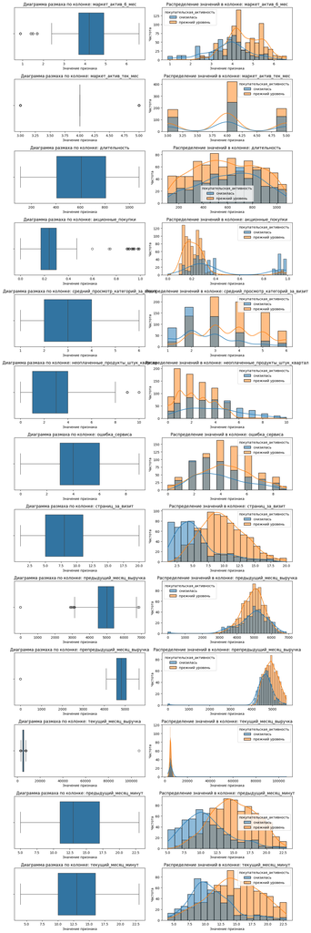

```python
plot_box_hist_chart(market, hue='покупательская_активность')
```

Заметен очень большой выброс в выручке по одному клиенту. Посмотрим, что это за клиент.

```python
market.query('текущий_месяц_выручка > 20000')
```

| id | покупательская_активность | тип_сервиса | разрешить_сообщать | маркет_актив_6_мес | маркет_актив_тек_мес | длительность | акционные_покупки | популярная_категория | средний_просмотр_категорий_за_визит | неоплаченные_продукты_штук_квартал | ошибка_сервиса | страниц_за_визит | предыдущий_месяц_выручка | препредыдущий_месяц_выручка | текущий_месяц_выручка | предыдущий_месяц_минут | текущий_месяц_минут |
| --- | --- | --- | --- | --- | --- | --- | --- | --- | --- | --- | --- | --- | --- | --- | --- | --- | --- |
| 215380 | снизилась | премиум | нет | 1.7 | 4 | 637 | 0.94 | техника для красоты и здоровья | 3 | 2 | 4 | 7 | 6077.0 | 5051.0 | 106862.2 | 12 | 14 |

```python
money.query('id == 215380')
```

|  | id | прибыль |
| --- | --- | --- |
| 32 | 215380 | 3.88 |

Однако, учитывая огромную разницу в сумме выручки с другими клиентами, наличие такого выброса в данных может существенно снизить качество модели машинного обучения. Поэтому от выброса а данных лучше избавиться.

Посколько аномальная запись всего 1 из 1300, то можем без последствий удалить ее из выборки.

```python
# удалим пользователя из всех файлов
market = market.query('id != 215380')
market_file = market_file.query('id != 215380')
market_money = market_money.query('id != 215380')
market_time = market_time.query('id != 215380')
money = money.query('id != 215380')
```

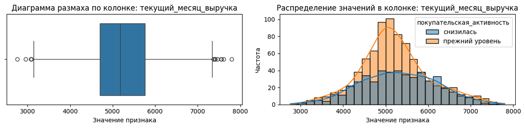

```python
# Распределение признака после удаления выброса
plot_box_hist_chart(market.query('текущий_месяц_выручка <= 20000')[['текущий_месяц_выручка', 'покупательская_активность']], hue='покупательская_активность')
```

Теперь распределение имеет нормальный вид.

**money**

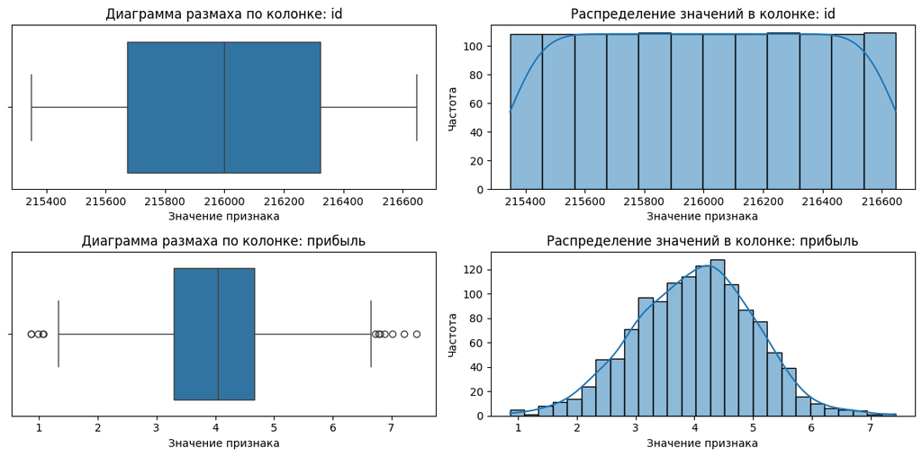

```python
plot_box_hist_chart(money)
```

**1. Выбросы и анализ числовых признаках:**

**`market`:**

- `маркет_актив_6_мес`: выбросы представляют собой покупателей, которым приходило 1-2 маркетинговых сообщений в последние 6 месяцев. Возможно это малоактивные пользователи или нецелевой сегмент магазина. Заметно, что пользователям с прежней активностью в среднем приходило больше маркетинговых сообщений за последние полгода.
- `маркет_актив_тек_мес`: было всего 3 категории пользователей, которым приходило 3,4,5 сообщений соответственно. Данные не являются выбросами.
- `акционные_покупки`: на графиках выделяется подгруппа пользователей с высокой долей покупок по акциям (>80%). Либо это новые пользователи, которые разово пришли по акциям и больше не делали заказы, либо постоянные, которые дожидаются акций на любимые товары. Заметно, что спад активности произошел в основном у любителей акций, возможно это связано с маркетинговой политикой компании в последнее время.
- `средний_просмотр_категорий_за_визит`: ПОльзователи с прежней активностью просматривают в среднем больше категорий товаров за визит, чем пользователи, у которых активность снизилась.
- `неоплаченные_продукты_штук_квартал`: небольшое количество пользователей имеют 9 или 10 продуктов в корзине, которые не были оплачены. В основном большое количество неоплаченных товаров имеет категория пользователей, у которых активность снизилась в последнее время.
- `ошибка_сервиса`: Категория пользователей со сниженной активностью даже немного реже сталкивалась с ошибками в работе сервиса. Вероятно это происходит по тому, что более активные пользователи больше времени проводят на сайте и чаще сталкиваются с ошибками. В целом, кажется, такие ошибки не сильно влияют на снижение активности пользователей.
- `страниц_за_визит`: Пользователи с прежней активность просматривают намного больше страниц за визит в среднем, чем пользователи с низкой активностью.
- `предыдущий_месяц_выручка` и `текущий_месяц_выручка`: Каких-то различий в размерах выручки клиентов с разной активностью в предыдущем месяце не выявлено. В колонке `текущий_месяц_выручка` заметен существенный выброс - один покупатель с очень большой выручкой. Вероятно, данный пользователей на самом деле совершил крупную покупку, однако наличие такого большого выброса может существенно снизить качество моделей классификации. ПОэтому данные об этом пользователе были удалены из всех таблиц.
- `препредыдущий_месяц_выручка`: Два месяца назад у категории пользователей со сниженной активностью наблюдалась более низкая выручка, чем у пользователей с прежним уровнем активности. Возможно, в последние два месяца компания начала менять свою маркетинговую политику и разница в предыдущем и в текущем месяца уже не так очевидна.
- `предыдущий_месяц_минут` и `текущий_месяц_минут`: В среднем пользователи с прежней активностью тратят больше времени на сайте, чем пользователи со сниженной активностью.

Других явных аномалий в количественных признаках таблицы `market` не видно, все значения находятся в рамках естественных и объяснимых границ и не являются аномалиями.

**`money`:**

- есть небольшие выбросы в колонке с прибылью, которую приносят клиенту интернет-магазина. Выбросы есть как справа, так и слева и объясняются естественными причинами. Не являются аномалиями

**2. Распределения числовых признаков:**

**`market`:**

- `маркет_актив_6_мес`: распределение признака близко к нормальному.
- `маркет_актив_тек_мес`:признак имеет всего 3 значения, что недостаточно для оценки формы распределения, но судя по распределению данных среди трех категорий оно также близко к нормальному.
- `длительность`: распеределение имеет вид нормального с широким колоколом, что делает его похожим на равномерное. Видно как число регистраций новый пользователей интернет-магазин сначала росло, но после какого-то момента начало снижаться. Это подтверждает первоначальное предположение о снижении эффективности привлечения новых клиентов.
- `акционные_покупки`: график показывает бимодальное распределением признака (два пика нормального распределения). Выделяется группа пользователей, покупающих преимущественно акционные товары.
- `средний_просмотр_категорий_за_визит`, `неоплаченные_продукты_штук_квартал`, `ошибка_сервиса`, `страниц_за_визит`: распределение блико к нормальному.
- `предыдущий_месяц_выручка`, `текущий_месяц_выручка` и `препредыдущий_месяц_выручка`: распределение признаков имеет вид нормального. На графике заметна небольшая группа пользователей с 0 выручкой, которые ничего не купили за прошедший период.
- `предыдущий_месяц_минут` и `текущий_месяц_минут`: признак распределен нормально

**`money`:**

- `прибыль`: признак распределен нормально.

#### Категориальные признаки

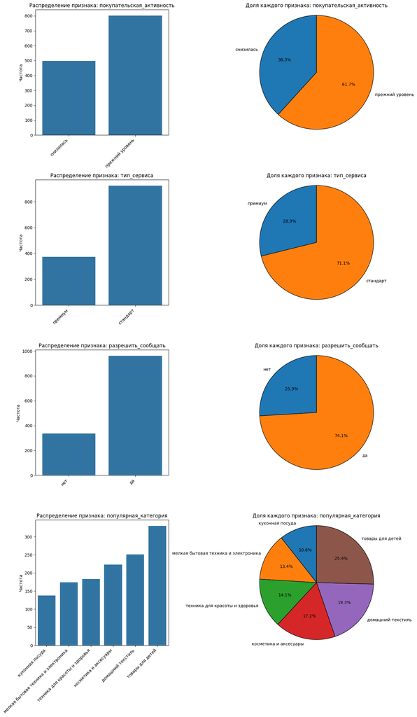

```python
plot_bar_pie_chart(market, y_label='Частота')
```

- `покупательская_активность`: Снижение активности наблюдается у 38% пользователей (у 62% она осталась на прежнем уровне). Учитывая, что это целевая переменная, то наличие небольшого дисбаланса классов может привести к тому, что модель может немного чаще предсказывать неизменность активности пользователей. А значит такие клиенты не будут учитываться при проведении маркетинговых мероприятий и магазин недополучит прибыль. При построении модели машинного обучения рекомендуется учитывать наличие такого дисбаланса в целевой переменной, чтобы избежать завышенной оценки покупателськой способности.
- `тип_сервиса`: Большинство пользователей (71%) относится к категории "стандарт".
- `разрешить сообщать`: Большиство пользователей (74%) согласно получать маркетинговые материалы.
- `популярная категория`: У пользователей в выборке есть 6 популярных категорий, наиболее популярная "товары для детей" (25.4%). Распределение по остальным категориям выглядит сбалансированно.

### Активность клиентов

Для целей построения модели выберем активных клиентов, т.е. только тех у которых были покупки в последние 3 месяца.

Этот показатель можно отследить по наличию у магазина выручки, полученной от данного клиента в любом из трех последних месяцев.

Удалим из выборки клиентов, у которых хотя бы в одном из 3х месяцев выручка была равно 0.

```python
# найдем неактивных клиентов
market[(market['препредыдущий_месяц_выручка'] == 0) |
       (market['предыдущий_месяц_выручка'] == 0) |
       (market['текущий_месяц_выручка'] == 0)]
```

| id | покупательская_активность | тип_сервиса | разрешить_сообщать | маркет_актив_6_мес | маркет_актив_тек_мес | длительность | акционные_покупки | популярная_категория | средний_просмотр_категорий_за_визит | неоплаченные_продукты_штук_квартал | ошибка_сервиса | страниц_за_визит | предыдущий_месяц_выручка | препредыдущий_месяц_выручка | текущий_месяц_выручка | предыдущий_месяц_минут | текущий_месяц_минут |
| --- | --- | --- | --- | --- | --- | --- | --- | --- | --- | --- | --- | --- | --- | --- | --- | --- | --- |
| 215348 | снизилась | премиум | да | 3.4 | 5 | 121 | 0.0 | товары для детей | 6 | 2 | 1 | 5 | 0.0 | 0.0 | 3293.1 | 13 | 14 |
| 215357 | снизилась | стандарт | да | 3.9 | 5 | 154 | 0.0 | техника для красоты и здоровья | 3 | 3 | 9 | 5 | 0.0 | 0.0 | 5986.3 | 12 | 6 |
| 215359 | снизилась | стандарт | да | 4.6 | 5 | 110 | 0.0 | домашний текстиль | 4 | 2 | 4 | 2 | 0.0 | 0.0 | 4735.0 | 13 | 11 |

```python
market.shape
```

```
(1299, 17)
```

В выборке есть 3 неактивных пользователя, уберем их из выборки.

```python
# Найдем индексы неактивных клиентов
inactive_clients_index = market[(market['препредыдущий_месяц_выручка'] == 0) |
                                 (market['предыдущий_месяц_выручка'] == 0) |
                                 (market['текущий_месяц_выручка'] == 0)].index

# Удалим неактивных клиентов из выборки
market = market.drop(inactive_clients_index)
```

```python
market.shape
```

```
(1296, 17)
```

### Снижение активности пользователей

```python
# временно добавим столбец с общей выручкой, чтобы проанализировать активность пользователей за все три периода
market['общая_выручка'] = market['препредыдущий_месяц_выручка'] + market['предыдущий_месяц_выручка']  + market['текущий_месяц_выручка']
```

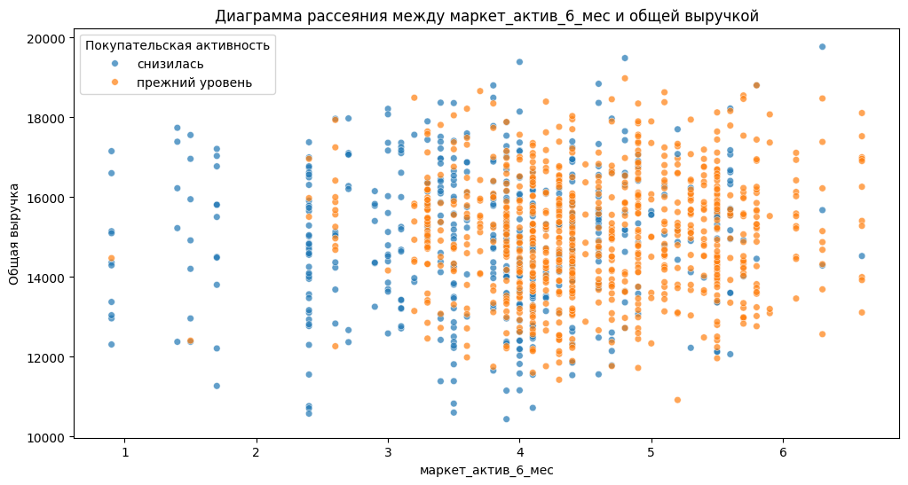

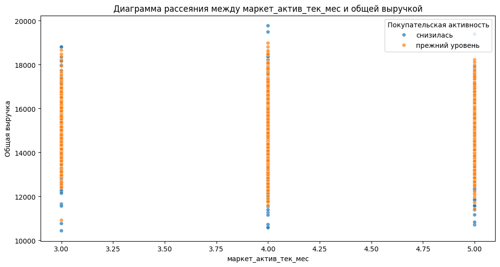

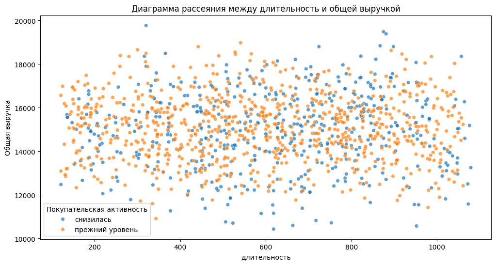

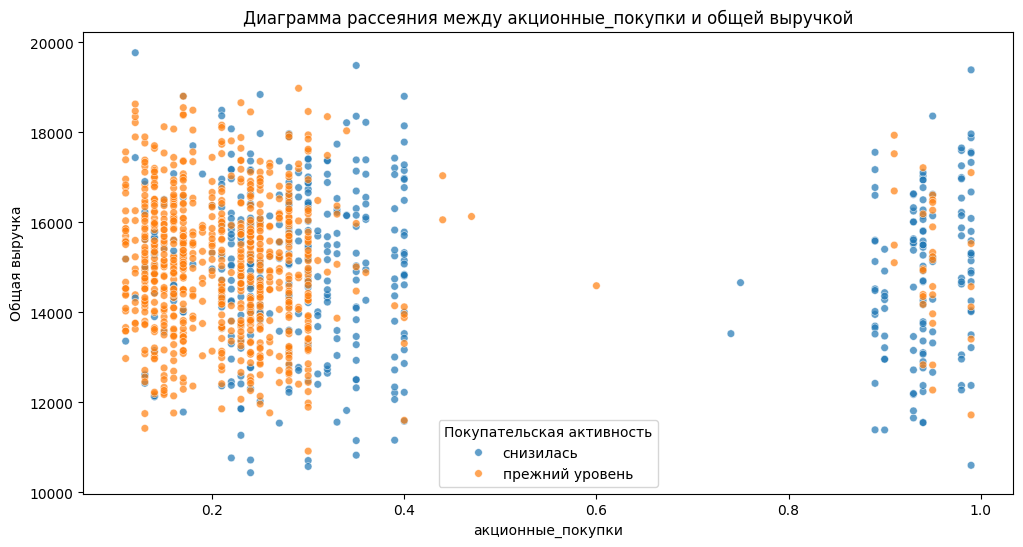

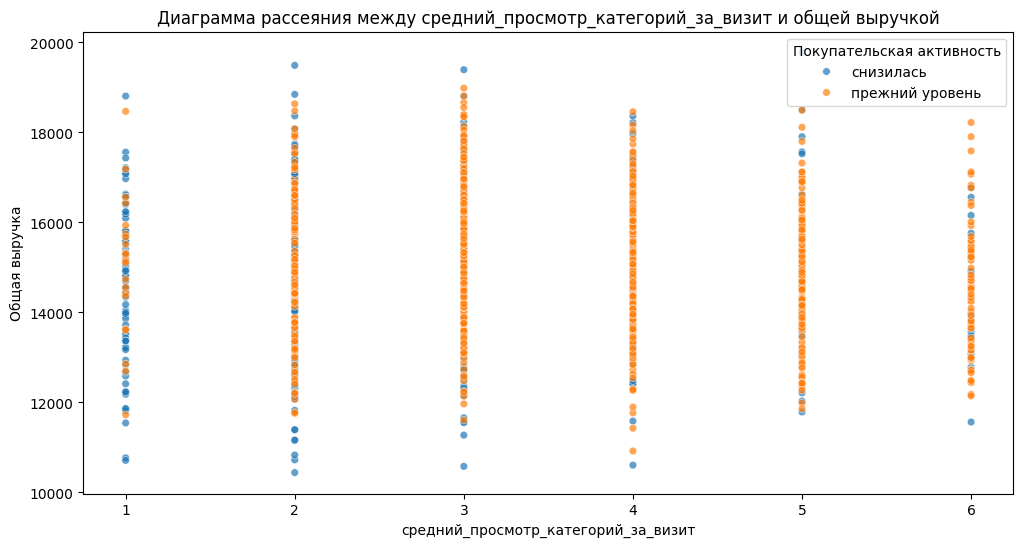

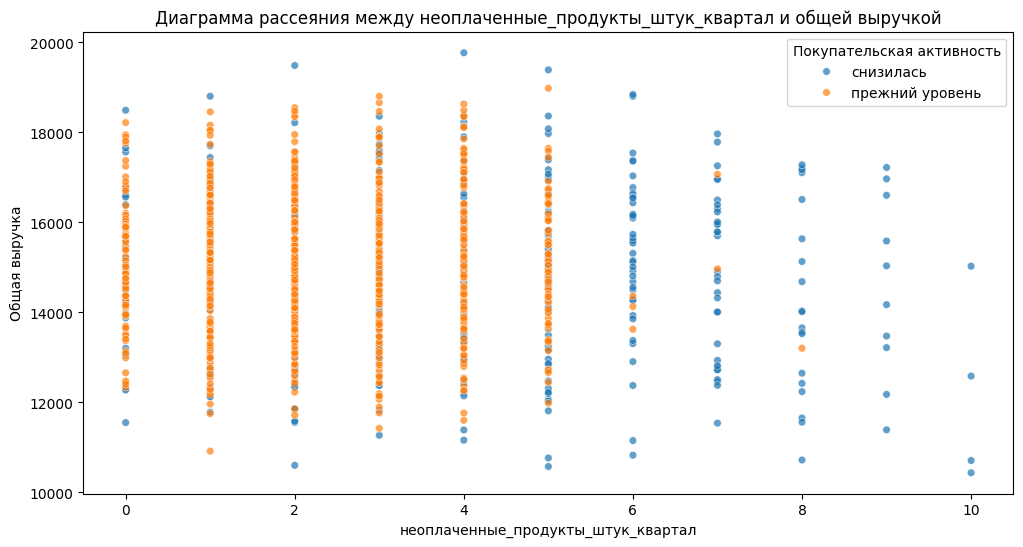

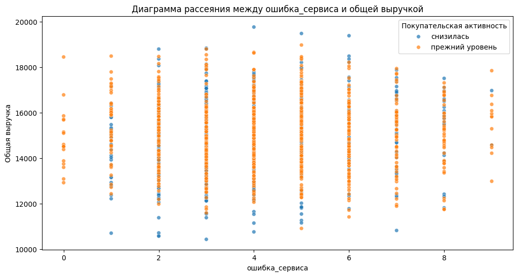

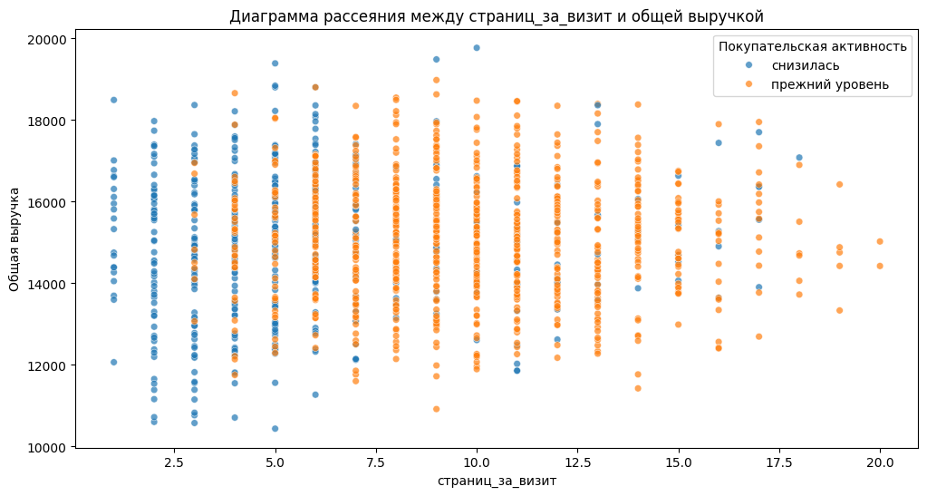

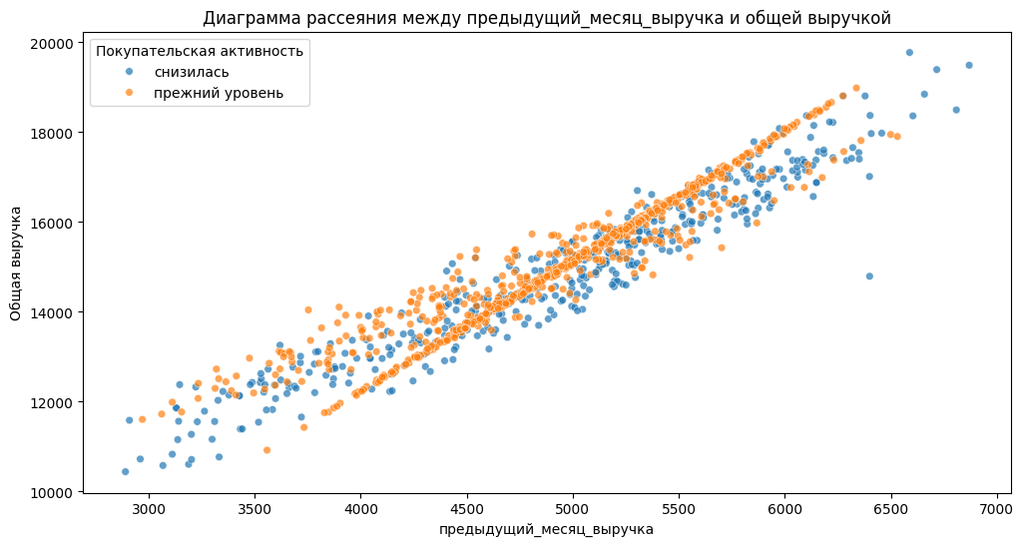

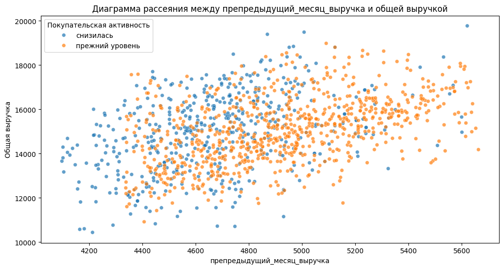

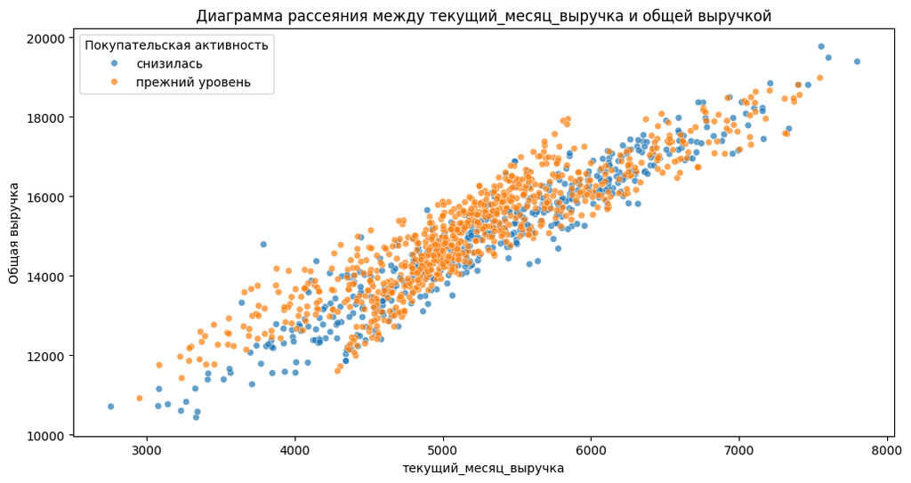

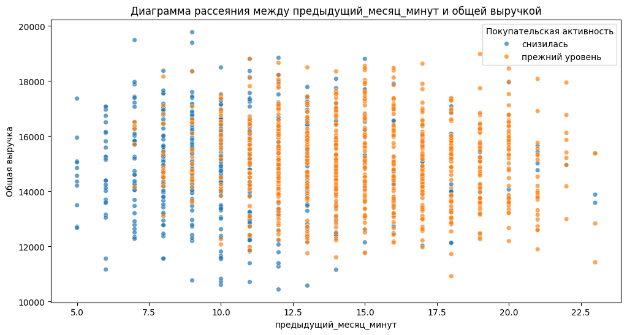

[1 more figures not shown]

```python
# Фильтруем только количественные данные
quantitative_cols = market.select_dtypes(include='number').columns

# Проходим по количественным столбцам для построения диаграмм рассеяния
for col in quantitative_cols:
    if col not in ['общая_выручка', 'покупательская_активность']:
        plt.figure(figsize=(12, 6))
        sns.scatterplot(data=market, x=col, y='общая_выручка', hue='покупательская_активность', alpha=0.7, s=30)
        plt.title(f'Диаграмма рассеяния между {col} и общей выручкой')
        plt.xlabel(col)
        plt.ylabel('Общая выручка')
        plt.legend(title='Покупательская активность')
        plt.show()
```

На графиках заметно, что сниженние активности налюдалась в основном среди:

- пользователей с большой долей покупок акционных товаров.
- пользователей с большим количество неоплаченных товаров в корзине.
- пользователей, посещяющих не более 3 страниц интернет-магазина.

На графике зависимости выручки предыдущего месяца и общей выручки заметна четкая прямая линия из покупателей с прежней активностью. Вероятно, это и есть наш целевой сегмент постоянных покупателей. Такие же, но чуть менее явные линии видны и на графиках зависимости общей выручки от выручки за предыдущие периоды.

Кроме того, на графиках заметно что связь между `акционные_покупки` и целевым признаком нелинейная. Выделяются две явные группы пользователей:

- в основном покупают только по акциям (более 80% покупок по акциям);
- не обращают внимание на акции (доля покупок по акциям <40%).

Учитывая нелинейнойсть связи, вероятно, лучше заменить признак `акционные_покупки` на **категориальный**, делящий пользователей на 2 категории:

- пользователи, которые чаще совершают покупки по акциям (>=50% покупок);и
- пользователи, которые чаще покупают товары без акций (<50% покупок).

```python
# Добавление нового столбца с условиями в таблицу
market['акционные_покупки_категория'] = market['акционные_покупки'].apply(lambda x: 'по_акциям' if x >= 0.5 else 'без_акций' if x < 0.5 else 'без категории')
```

```python
market.head()
```

| id | покупательская_активность | тип_сервиса | разрешить_сообщать | маркет_актив_6_мес | маркет_актив_тек_мес | длительность | акционные_покупки | популярная_категория | средний_просмотр_категорий_за_визит | неоплаченные_продукты_штук_квартал | ошибка_сервиса | страниц_за_визит | предыдущий_месяц_выручка | препредыдущий_месяц_выручка | текущий_месяц_выручка | предыдущий_месяц_минут | текущий_месяц_минут | общая_выручка | акционные_покупки_категория |
| --- | --- | --- | --- | --- | --- | --- | --- | --- | --- | --- | --- | --- | --- | --- | --- | --- | --- | --- | --- |
| 215349 | снизилась | премиум | да | 4.4 | 4 | 819 | 0.75 | товары для детей | 4 | 4 | 2 | 5 | 5216.0 | 4472.0 | 4971.6 | 12 | 10 | 14659.6 | по_акциям |
| 215350 | снизилась | стандарт | нет | 4.9 | 3 | 539 | 0.14 | домашний текстиль | 5 | 2 | 1 | 5 | 5457.5 | 4826.0 | 5058.4 | 8 | 13 | 15341.9 | без_акций |
| 215351 | снизилась | стандарт | да | 3.2 | 5 | 896 | 0.99 | товары для детей | 5 | 0 | 6 | 4 | 6158.0 | 4793.0 | 6610.4 | 11 | 13 | 17561.4 | по_акциям |
| 215352 | снизилась | стандарт | нет | 5.1 | 3 | 1064 | 0.94 | товары для детей | 3 | 2 | 3 | 2 | 5807.5 | 4594.0 | 5872.5 | 8 | 11 | 16274.0 | по_акциям |
| 215353 | снизилась | стандарт | да | 3.3 | 4 | 762 | 0.26 | домашний текстиль | 4 | 1 | 1 | 4 | 4738.5 | 5124.0 | 5388.5 | 10 | 10 | 15251.0 | без_акций |

```python
market['акционные_покупки_категория'].value_counts()
```

| акционные_покупки_категория | count |
| --- | --- |
| без_акций | 1129 |
| по_акциям | 167 |

**dtype:** int64

```python
market.head()
```

| id | покупательская_активность | тип_сервиса | разрешить_сообщать | маркет_актив_6_мес | маркет_актив_тек_мес | длительность | акционные_покупки | популярная_категория | средний_просмотр_категорий_за_визит | неоплаченные_продукты_штук_квартал | ошибка_сервиса | страниц_за_визит | предыдущий_месяц_выручка | препредыдущий_месяц_выручка | текущий_месяц_выручка | предыдущий_месяц_минут | текущий_месяц_минут | общая_выручка | акционные_покупки_категория |
| --- | --- | --- | --- | --- | --- | --- | --- | --- | --- | --- | --- | --- | --- | --- | --- | --- | --- | --- | --- |
| 215349 | снизилась | премиум | да | 4.4 | 4 | 819 | 0.75 | товары для детей | 4 | 4 | 2 | 5 | 5216.0 | 4472.0 | 4971.6 | 12 | 10 | 14659.6 | по_акциям |
| 215350 | снизилась | стандарт | нет | 4.9 | 3 | 539 | 0.14 | домашний текстиль | 5 | 2 | 1 | 5 | 5457.5 | 4826.0 | 5058.4 | 8 | 13 | 15341.9 | без_акций |
| 215351 | снизилась | стандарт | да | 3.2 | 5 | 896 | 0.99 | товары для детей | 5 | 0 | 6 | 4 | 6158.0 | 4793.0 | 6610.4 | 11 | 13 | 17561.4 | по_акциям |
| 215352 | снизилась | стандарт | нет | 5.1 | 3 | 1064 | 0.94 | товары для детей | 3 | 2 | 3 | 2 | 5807.5 | 4594.0 | 5872.5 | 8 | 11 | 16274.0 | по_акциям |
| 215353 | снизилась | стандарт | да | 3.3 | 4 | 762 | 0.26 | домашний текстиль | 4 | 1 | 1 | 4 | 4738.5 | 5124.0 | 5388.5 | 10 | 10 | 15251.0 | без_акций |

### Выводы

1. **Основные характеристики пользователей**
- *Количество пользователей*: 1300 с уникальными идентификаторами от 215348 до 216647.
- *Покупательская активность*: У большинства пользователей уровень активности остался прежним.
- *Тип сервиса*: Преобладает стандартный тип сервиса.
- *Разрешение на сообщения*: Большинство пользователей согласны получать уведомления.
- *Маркетинговая активность*: Среднее количество сообщений за последние 6 месяцев составляет 4.25, что немного ниже в текущем месяце (4.01).
- *Длительность регистрации*: Средний срок регистрации пользователей — около 602 дней.
- *Акционные покупки*: Около 25% покупок совершаются по акциям.
- *Популярная категория*: Товары для детей.
2. **Выбросы и аномалии**
- *Выбросы*: Один пользователь с аномально высокой выручкой был удалён из выборки, так как его данные могли исказить качество моделей.
- *Числовые признаки*: В основном, выбросы не наблюдаются, за исключением некоторых категорий, где пользователи получали минимальное количество сообщений или имели высокую долю акционных покупок.
3. **Распределения признаков**
- *Числовые признаки* имеют нормальное распределение, за исключением акционных покупок, которые демонстрируют бимодальное распределение.
- *Категориальные признаки*: 38% пользователей показали снижение активности, что может привести к недостаточной предсказательной способности модели.
4. **Объединение данных**
- Данные о выручке и времени на сайте успешно объединены, что позволяет провести дальнейший анализ.
5. **Снижение активности пользователей**

Снижение активности наблюдается среди:

- Пользователей с высокой долей акционных покупок.
- Пользователей с большим количеством неоплаченных товаров.
- Пользователей, посещающих менее 3 страниц за визит.
6. **Наблюдения**
- *Дисбаланс классов*: Возмождно стоит учесть дисбаланс в целевой переменной при построении моделей.

## Корреляционный анализ

Построим диаграмму рассеивания по всем признакам в таблице `market`.

```python
quantitative_cols = market.select_dtypes(include=['number']).columns.tolist()
```

```python
market[quantitative_cols]
```

| id | маркет_актив_6_мес | маркет_актив_тек_мес | длительность | акционные_покупки | средний_просмотр_категорий_за_визит | неоплаченные_продукты_штук_квартал | ошибка_сервиса | страниц_за_визит | предыдущий_месяц_выручка | препредыдущий_месяц_выручка | текущий_месяц_выручка | предыдущий_месяц_минут | текущий_месяц_минут | общая_выручка |
| --- | --- | --- | --- | --- | --- | --- | --- | --- | --- | --- | --- | --- | --- | --- |
| 215349 | 4.4 | 4 | 819 | 0.75 | 4 | 4 | 2 | 5 | 5216.0 | 4472.0 | 4971.6 | 12 | 10 | 14659.6 |
| 215350 | 4.9 | 3 | 539 | 0.14 | 5 | 2 | 1 | 5 | 5457.5 | 4826.0 | 5058.4 | 8 | 13 | 15341.9 |
| 215351 | 3.2 | 5 | 896 | 0.99 | 5 | 0 | 6 | 4 | 6158.0 | 4793.0 | 6610.4 | 11 | 13 | 17561.4 |
| 215352 | 5.1 | 3 | 1064 | 0.94 | 3 | 2 | 3 | 2 | 5807.5 | 4594.0 | 5872.5 | 8 | 11 | 16274.0 |
| 215353 | 3.3 | 4 | 762 | 0.26 | 4 | 1 | 1 | 4 | 4738.5 | 5124.0 | 5388.5 | 10 | 10 | 15251.0 |
| ... | ... | ... | ... | ... | ... | ... | ... | ... | ... | ... | ... | ... | ... | ... |
| 216643 | 6.6 | 3 | 318 | 0.24 | 5 | 3 | 3 | 11 | 3664.0 | 4704.0 | 4741.7 | 14 | 7 | 13109.7 |
| 216644 | 5.1 | 4 | 454 | 0.21 | 6 | 2 | 3 | 9 | 4729.0 | 5299.0 | 5353.0 | 12 | 11 | 15381.0 |
| 216645 | 4.1 | 3 | 586 | 0.20 | 3 | 2 | 5 | 7 | 5160.0 | 5334.0 | 5139.2 | 12 | 18 | 15633.2 |
| 216646 | 6.3 | 5 | 645 | 0.12 | 3 | 3 | 5 | 7 | 4923.0 | 4725.0 | 5224.6 | 18 | 7 | 14872.6 |
| 216647 | 4.0 | 5 | 906 | 0.94 | 4 | 5 | 3 | 12 | 4720.0 | 5183.0 | 4448.3 | 15 | 10 | 14351.3 |

1296 rows × 14 columns

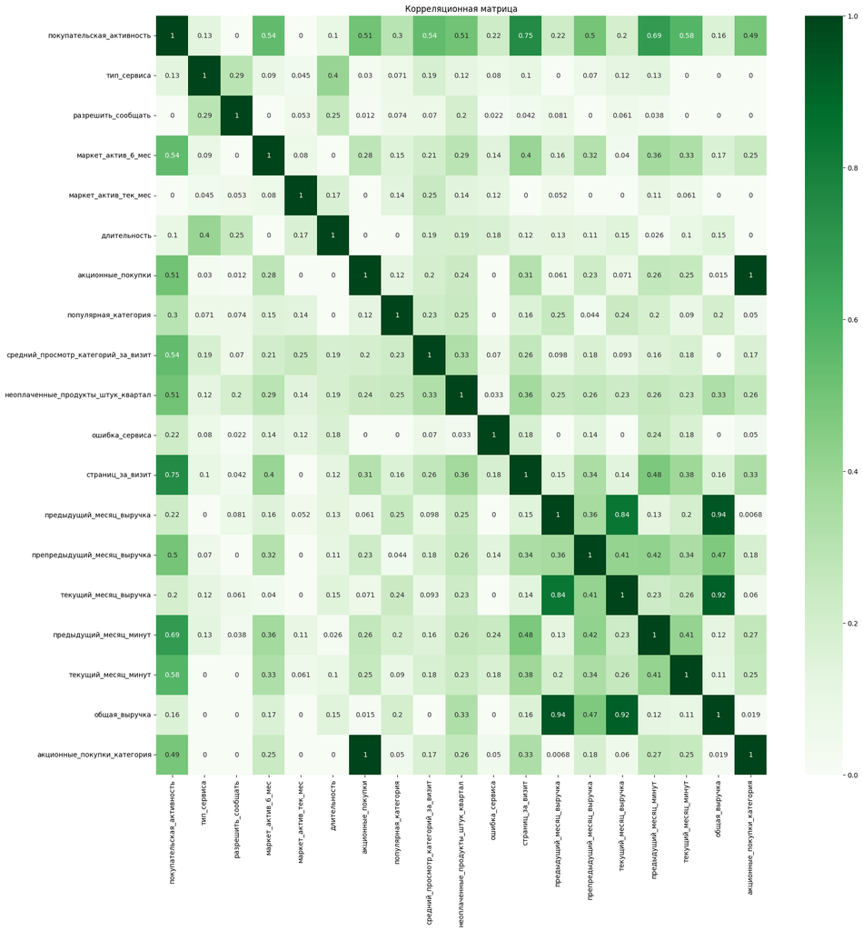

```python
# построим корреляционную матрицу по таблице всей таблицу market
plt.figure(figsize=(20, 20))
sns.heatmap(market
            .phik_matrix(interval_cols=quantitative_cols),
            annot=True,
            cmap='Greens'
           )
plt.title("Корреляционная матрица")
plt.show()
```

Отдельно посмотрим на корреляции в разрезе по целевому признаку.

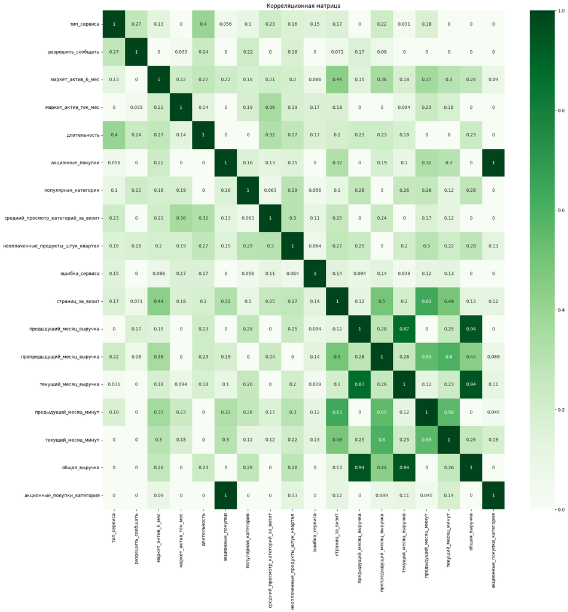

```python
# построим корреляционную матрицу по таблице всей таблицу market
plt.figure(figsize=(20, 20))
sns.heatmap(market.query('покупательская_активность == "снизилась"')
            .phik_matrix(interval_cols=quantitative_cols),
            annot=True,
            cmap='Greens'
           )
plt.title("Корреляционная матрица")
plt.show()
```

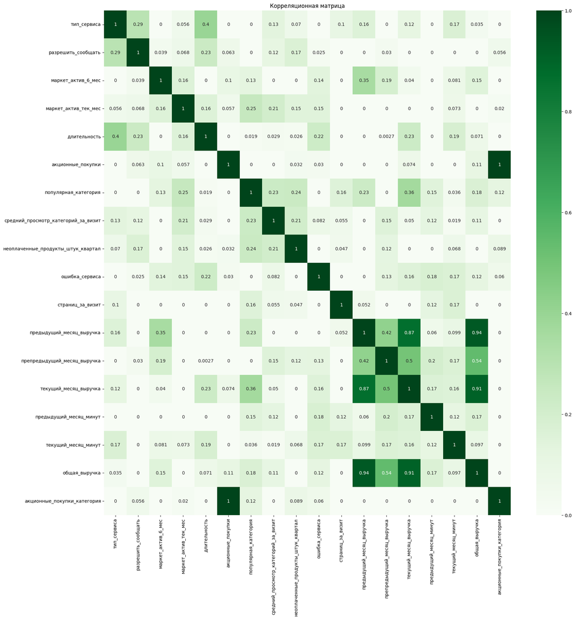

```python
# построим корреляционную матрицу по таблице всей таблицу market
plt.figure(figsize=(20, 20))
sns.heatmap(market.query('покупательская_активность == "прежний уровень"')
            .phik_matrix(interval_cols=quantitative_cols),
            annot=True,
            cmap='Greens'
           )
plt.title("Корреляционная матрица")
plt.show()
```

```python
market.drop('общая_выручка', axis=1, inplace=True)
```

Также поступим и с колонкой "акционные_покупки".

```python
market.drop('акционные_покупки', axis=1, inplace=True)
```

### Выводы

Следующие признаки были исключены для избежания мультиколлинеарности:

- общая_выручка
- акционные_покупки

## Обучение моделей

### Описание признаков и выбор метрики

**Целевая переменная:** `покупательская_активность`

**Категориальные признаки (неранговые):**

- `тип_сервиса`
- `разрешить_сообщать`,
- `популярная_категория`

**Категориальные признаки (ранговые):**

- `акционные_покупки_категория`

**Количественные признаки:**

- `маркет_актив_6_мес`,
- `маркет_актив_тек_мес`,
- `длительность`,
- `средний_просмотр_категорий_за_визит`,
- `неоплаченные_продукты_штук_квартал`,
- `ошибка_сервиса`,
- `страниц_за_визит`,
- `препредыдущий_месяц_выручка`,
- `предыдущий_месяц_выручка`,
- `текущий_месяц_выручка`,
- `предыдущий_месяц_минут`,
- `текущий_месяц_минут`

**Выбор метрики:**

- **ROC-AUC**: Метрика поможет оценить общее качество работы модели вне зависимости от выбранного порога вероятности. Метрику можно использовать в случае, когда объектов с одним значением целевого признака больше, чем с другими. Метрика поможет выбрать лучшую модель.
- **Recall (TPR)**: Важно не упустить клиентов, активность которых снизилась, чтобы направить им персонализированную рекламу. Ложноположительные результаты при этом не критичны (желательно минимизировать FN и максимизировать Recall). Метрика поможет в калибровке лучшей модели, выбранной с учетом ROC-AUC.

### Подготовка данных

```python
# Разделим данные на тренировочный и временный набор (тренировочный + валидационный_тестовый)
X_train, X_test_valid, y_train, y_test_valid = train_test_split(
    market.drop(['покупательская_активность'], axis=1),
    market['покупательская_активность'],
    test_size=TEST_VALID_SIZE,
    random_state=RANDOM_STATE,
    stratify=market['покупательская_активность']
)

# Теперь разделим валидационный_тестовый набор на валидационный и тестовый
X_valid, X_test, y_valid, y_test = train_test_split(
    X_test_valid,
    y_test_valid,
    test_size=VALID_SIZE,
    random_state=RANDOM_STATE,
    stratify=y_test_valid
)

# Проверим размеры выборок
X_train.shape, X_valid.shape, X_test.shape
```

```
((777, 16), (259, 16), (260, 16))
```

```python
y_train.unique()
```

```
array(['прежний уровень', 'снизилась'], dtype=object)
```

```python
# проверим кодировку
print(y_train[:3,])
print(y_valid[:3,])
print(y_test[:3,])
```

```
id
216375    прежний уровень
216325    прежний уровень
216286    прежний уровень
Name: покупательская_активность, dtype: object
id
216361    прежний уровень
216265    прежний уровень
215837          снизилась
Name: покупательская_активность, dtype: object
id
215746          снизилась
215616          снизилась
215951    прежний уровень
Name: покупательская_активность, dtype: object
```

```python
# Закодируем целевой признак
label_encoder = LabelEncoder()

# Зададим порядок кодирования, чтобы "снизилась" закодировалось 1.
y_label_classes = ['прежний уровень', 'снизилась']

label_encoder.fit(y_label_classes)

y_train = label_encoder.transform(y_train)
y_valid = label_encoder.transform(y_valid)
y_test = label_encoder.transform(y_test)
```

```python
# проверим кодировку
print(y_train[:3,])
print(y_valid[:3,])
print(y_test[:3,])
```

```
[0 0 0]
[0 0 1]
[1 1 0]
```

```python
# выведем названия закодированных классов [0, 1] соответственно
label_encoder.classes_
```

```
array(['прежний уровень', 'снизилась'], dtype='<U15')
```

### Создание пайплайнов

```python
# Создадим списки с названиями признаков

target_column =['покупательская_активность']

ohe_columns = [
    'тип_сервиса',
    'разрешить_сообщать',
    'популярная_категория'
]

ord_columns = ['акционные_покупки_категория']

num_columns = [
    'маркет_актив_6_мес',
    'маркет_актив_тек_мес',
    'длительность',
    'средний_просмотр_категорий_за_визит',
    'неоплаченные_продукты_штук_квартал',
    'ошибка_сервиса',
    'страниц_за_визит',
    'препредыдущий_месяц_выручка',
    'предыдущий_месяц_выручка',
    'текущий_месяц_выручка',
    'предыдущий_месяц_минут',
    'текущий_месяц_минут'
]
```

```python
# создаём пайплайн для подготовки признаков из списка ohe_columns: заполнение пропусков и OHE-кодирование
# SimpleImputer + OHE
ohe_pipe = Pipeline(
    [('simpleImputer_ohe', SimpleImputer(missing_values=np.nan, strategy='most_frequent', add_indicator=False)),
     ('ohe', OneHotEncoder(drop='first', handle_unknown='error', sparse_output=False))
    ]
)
```

```python
# создаём пайплайн для подготовки признаков из списка ord_columns: заполнение пропусков и Ordinal-кодирование
# SimpleImputer + OE
ord_pipe = Pipeline(
    [('simpleImputer_before_ord', SimpleImputer(missing_values=np.nan, strategy='most_frequent')),
     ('ord',  OrdinalEncoder(
                categories=[
                    ['без_акций', 'по_акциям']
                ],
                handle_unknown='use_encoded_value', unknown_value=np.nan
            )
        ),
     ('simpleImputer_after_ord', SimpleImputer(missing_values=np.nan, strategy='most_frequent'))
    ]
)
```

```python
data_preprocessor = ColumnTransformer(
    [('ohe', ohe_pipe, ohe_columns),
     ('ord', ord_pipe, ord_columns),
     ('num', StandardScaler(), num_columns)
    ],
    remainder='passthrough'
)
```

```python
# создаём итоговый пайплайн с базовой моделью логистической регрессии
pipe_final = Pipeline([
    ('preprocessor', data_preprocessor),
    ('models', LogisticRegression(random_state=RANDOM_STATE))
])
```

```python
# учитывая, что возможно мы захотим поэксперементировать с добавление новых признаков и устранением дисбаланса классов
# создадим расширенную версию пайплайна для этого
pipe_final_imb = ImbPipeline([
    ('preprocessor', data_preprocessor),
    ('poly', 'passthrough'),
    ('sampler', 'passthrough'),
    ('models', LogisticRegression(random_state=RANDOM_STATE))
])
```

### Поиск лучшей модели

#### Базовая модель логистической регрессии

```python
# списки для хранения данных об обученных моделях
pipelines_names = []
pipelines = []
train_auc_cv = []
valid_auc = []
```

```python
pipe_final.fit(X_train, y_train)

y_valid_pred = pipe_final.predict(X_valid)
y_valid_proba = pipe_final.predict_proba(X_valid)[:, 1]

print(f'Метрика ROC-AUC на кросс-валидации (тренировочная выборка): {cross_val_score(pipe_final, X_train, y_train, cv=5, scoring="roc_auc").mean()}')
print(f'Метрика ROC-AUC на валидационной выборке: {roc_auc_score(y_valid, y_valid_proba)}')
base_model = pipe_final
```

```
Метрика ROC-AUC на кросс-валидации (тренировочная выборка): 0.8938787749723339
Метрика ROC-AUC на валидационной выборке: 0.9271464646464648
```

```python
# Сохраним результаты в соответствующие списки
pipelines_names.append('base_model')
pipelines.append(base_model)
train_auc_cv.append(cross_val_score(pipe_final, X_train, y_train, cv=5, scoring="roc_auc").mean())
valid_auc.append(roc_auc_score(y_valid, y_valid_proba))
```

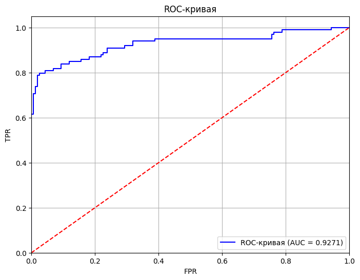

```python
plot_roc_curve(y_valid, y_valid_proba)
```

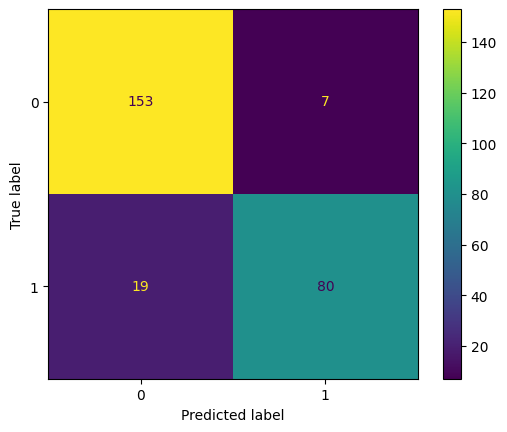

```python
# построим матрицу ошибок
plot_confusion_matrix(pipe_final, X_valid, y_valid)
```

Неплохое качество у базовой модели, но посмотрим можно ли лучше.

#### Подбор модели и гиперпараметров

##### RandomizedSearchCV

Попробуем перебрать разные варианты моделей и гиперпараметров с помощью RandomizedSearchCV, т.к. количество возможных вариантов достаточно велико для перебора другими методами:

```python
param_grid_randomized = [
    {
        'models': [DecisionTreeClassifier(random_state=RANDOM_STATE)],
        'models__max_depth': range(1, 31),
        'models__min_samples_split': range(2, 21),
        'models__min_samples_leaf': range(1, 21),
        'preprocessor__num': [StandardScaler(), MinMaxScaler(), 'passthrough']
    },
    {
        'models': [KNeighborsClassifier()],
        'models__n_neighbors': range(1, 51),
        'preprocessor__num': [StandardScaler(), MinMaxScaler(), 'passthrough']
    },
    {
        'models': [LogisticRegression(random_state=RANDOM_STATE, solver='liblinear', penalty='l1')],
        'models__C': [0.001, 0.01, 0.1, 1, 10, 100, 1000],
        'preprocessor__num': [StandardScaler(), MinMaxScaler(), 'passthrough']
    },
    {
        'models': [SVC(random_state=RANDOM_STATE, probability=True)],
        'models__C': [0.001, 0.01, 0.1, 1, 10, 100, 1000],
        'models__gamma': [0.001, 0.01, 0.1, 1],
        'preprocessor__num': [StandardScaler(), MinMaxScaler(), 'passthrough']
    }
]
```

```
Лучшая модель и её параметры:
```

```
Pipeline(steps=[('preprocessor',
                 ColumnTransformer(remainder='passthrough',
                                   transformers=[('ohe',
                                                  Pipeline(steps=[('simpleImputer_ohe',
                                                                   SimpleImputer(strategy='most_frequent')),
                                                                  ('ohe',
                                                                   OneHotEncoder(drop='first',
                                                                                 sparse_output=False))]),
                                                  ['тип_сервиса',
                                                   'разрешить_сообщать',
                                                   'популярная_категория']),
                                                 ('ord',
                                                  Pipeline(steps=[('simpleImputer_before_ord',
                                                                   SimpleI...
                                                   'средний_просмотр_категорий_за_визит',
                                                   'неоплаченные_продукты_штук_квартал',
                                                   'ошибка_сервиса',
                                                   'страниц_за_визит',
                                                   'препредыдущий_месяц_выручка',
                                                   'предыдущий_месяц_выручка',
                                                   'текущий_месяц_выручка',
                                                   'предыдущий_месяц_минут',
                                                   'текущий_месяц_минут'])])),
                ('models',
                 DecisionTreeClassifier(max_depth=10, min_samples_leaf=15,
                                        min_samples_split=19,
                                        random_state=42))])
```

```
Метрика лучшей модели ROC-AUC на кросс-валидации (тренировочная выборка): 0.8836387347836215
Метрика ROC-AUC на валидационной выборке: 0.8929924242424243
```

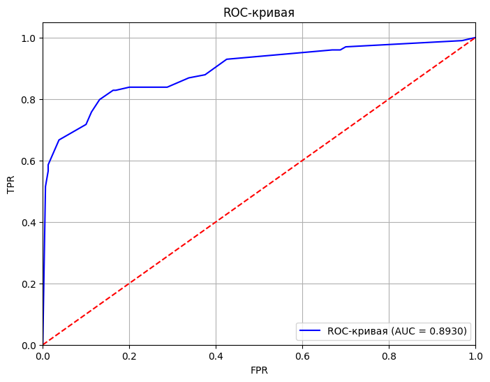

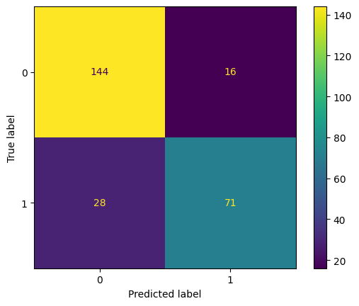

|  | rank_test_score | param_models | mean_test_score | params |
| --- | --- | --- | --- | --- |
| 183 | 1 | DecisionTreeClassifier(random_state=42) | 0.883639 | {'preprocessor__num': 'passthrough', 'models__... |
| 149 | 2 | DecisionTreeClassifier(random_state=42) | 0.883203 | {'preprocessor__num': StandardScaler(), 'model... |
| 112 | 2 | DecisionTreeClassifier(random_state=42) | 0.883203 | {'preprocessor__num': 'passthrough', 'models__... |
| 92 | 2 | DecisionTreeClassifier(random_state=42) | 0.883203 | {'preprocessor__num': MinMaxScaler(), 'models_... |
| 173 | 2 | DecisionTreeClassifier(random_state=42) | 0.883203 | {'preprocessor__num': 'passthrough', 'models__... |

```
CPU times: user 1.95 s, sys: 226 ms, total: 2.18 s
Wall time: 19.2 s
```

```python
%%time

randomized_search, results = find_best_model_randomized(
    pipe_final,
    param_grid_randomized
)
print()
```

```python
# Сохраним результаты в соответствующие списки
pipelines_names.append('randomized_search.best_estimator_')
pipelines.append(randomized_search.best_estimator_)
train_auc_cv.append(randomized_search.best_score_)
valid_auc.append(roc_auc_score(y_valid, randomized_search.predict_proba(X_valid)[:, 1]))
```

Метрики стали хуже, чем было у базовой модели. Видимо алгоритм случайного поиск не справился с поиском лучшей модели, даже с большим числом итераций (200). Возможно количество попыток было недостаточным.

Чтобы сильно не увеличивать число попыток и время поиска, попробуем использовать другой алгоритм OptunaSearch.

##### OptunaSearchCV

В отличии от RandomizedSearchCV в OptunaSearchCV сетку параметров нужно подавать в виде словаря, а не списка.

Поэтому немного адаптируем сетку с входящими параметрами под новый инструмент. Так как один словарь представляет собой одну модель с различными настройками гиперпараметров, то перебирать модели придется в цикле.

```python
param_grid_optuna = [
    {
        'models': distributions.CategoricalDistribution([DecisionTreeClassifier(random_state=RANDOM_STATE)]),
        'models__max_depth': distributions.IntDistribution(1, 30),
        'models__min_samples_split': distributions.IntDistribution(2, 20),
        'models__min_samples_leaf': distributions.IntDistribution(1, 20),
        'preprocessor__num': distributions.CategoricalDistribution([StandardScaler(), MinMaxScaler(), 'passthrough'])
    },
    {
        'models': distributions.CategoricalDistribution([KNeighborsClassifier()]),
        'models__n_neighbors': distributions.IntDistribution(1, 50),
        'preprocessor__num': distributions.CategoricalDistribution([StandardScaler(), MinMaxScaler(), 'passthrough'])
    },
    {
        'models': distributions.CategoricalDistribution([LogisticRegression(
            random_state=RANDOM_STATE,
            solver='liblinear',
            penalty='l1'
        )]),
        'models__C': distributions.FloatDistribution(0.001, 100),
        'preprocessor__num': distributions.CategoricalDistribution([StandardScaler(), MinMaxScaler(), 'passthrough'])
    },
    {
        'models': distributions.CategoricalDistribution([SVC(random_state=RANDOM_STATE, probability=True)]),
        'models__C': distributions.FloatDistribution(0.001, 100),
        'models__gamma': distributions.FloatDistribution(0.001, 1),
        'preprocessor__num': distributions.CategoricalDistribution([StandardScaler(), MinMaxScaler(), 'passthrough'])
    }
]
```

```
Лучшая модель: DecisionTreeClassifier с параметрами:
```

```
Pipeline(steps=[('preprocessor',
                 ColumnTransformer(remainder='passthrough',
                                   transformers=[('ohe',
                                                  Pipeline(steps=[('simpleImputer_ohe',
                                                                   SimpleImputer(strategy='most_frequent')),
                                                                  ('ohe',
                                                                   OneHotEncoder(drop='first',
                                                                                 sparse_output=False))]),
                                                  ['тип_сервиса',
                                                   'разрешить_сообщать',
                                                   'популярная_категория']),
                                                 ('ord',
                                                  Pipeline(steps=[('simpleImputer_before_ord',
                                                                   SimpleI...
                                                   'средний_просмотр_категорий_за_визит',
                                                   'неоплаченные_продукты_штук_квартал',
                                                   'ошибка_сервиса',
                                                   'страниц_за_визит',
                                                   'препредыдущий_месяц_выручка',
                                                   'предыдущий_месяц_выручка',
                                                   'текущий_месяц_выручка',
                                                   'предыдущий_месяц_минут',
                                                   'текущий_месяц_минут'])])),
                ('models',
                 DecisionTreeClassifier(max_depth=14, min_samples_leaf=10,
                                        min_samples_split=20,
                                        random_state=42))])
```

```
Лучшая оценка ROC_AUC (кросс-валидация) на обучающем наборе: 0.8832025137359969
ROC-AUC оценка на валидационном наборе: 0.8945391414141415
```

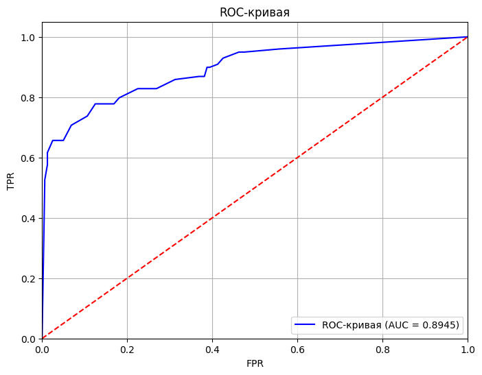

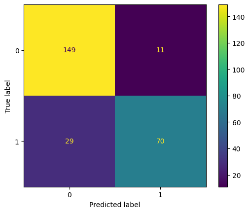

```
Лучшая модель: KNeighborsClassifier с параметрами:
```

```
Pipeline(steps=[('preprocessor',
                 ColumnTransformer(remainder='passthrough',
                                   transformers=[('ohe',
                                                  Pipeline(steps=[('simpleImputer_ohe',
                                                                   SimpleImputer(strategy='most_frequent')),
                                                                  ('ohe',
                                                                   OneHotEncoder(drop='first',
                                                                                 sparse_output=False))]),
                                                  ['тип_сервиса',
                                                   'разрешить_сообщать',
                                                   'популярная_категория']),
                                                 ('ord',
                                                  Pipeline(steps=[('simpleImputer_before_ord',
                                                                   SimpleI...
                                                  ['маркет_актив_6_мес',
                                                   'маркет_актив_тек_мес',
                                                   'длительность',
                                                   'средний_просмотр_категорий_за_визит',
                                                   'неоплаченные_продукты_штук_квартал',
                                                   'ошибка_сервиса',
                                                   'страниц_за_визит',
                                                   'препредыдущий_месяц_выручка',
                                                   'предыдущий_месяц_выручка',
                                                   'текущий_месяц_выручка',
                                                   'предыдущий_месяц_минут',
                                                   'текущий_месяц_минут'])])),
                ('models', KNeighborsClassifier(n_neighbors=20))])
```

```
Лучшая оценка ROC_AUC (кросс-валидация) на обучающем наборе: 0.8941394039887782
ROC-AUC оценка на валидационном наборе: 0.9049242424242424
```

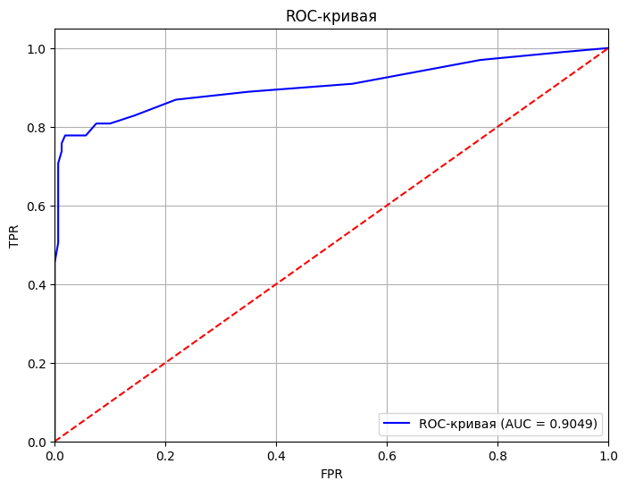

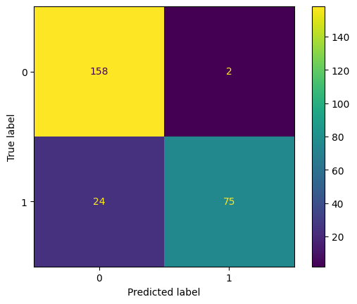

```
Лучшая модель: LogisticRegression с параметрами:
```

```
Pipeline(steps=[('preprocessor',
                 ColumnTransformer(remainder='passthrough',
                                   transformers=[('ohe',
                                                  Pipeline(steps=[('simpleImputer_ohe',
                                                                   SimpleImputer(strategy='most_frequent')),
                                                                  ('ohe',
                                                                   OneHotEncoder(drop='first',
                                                                                 sparse_output=False))]),
                                                  ['тип_сервиса',
                                                   'разрешить_сообщать',
                                                   'популярная_категория']),
                                                 ('ord',
                                                  Pipeline(steps=[('simpleImputer_before_ord',
                                                                   SimpleI...
                                                   'длительность',
                                                   'средний_просмотр_категорий_за_визит',
                                                   'неоплаченные_продукты_штук_квартал',
                                                   'ошибка_сервиса',
                                                   'страниц_за_визит',
                                                   'препредыдущий_месяц_выручка',
                                                   'предыдущий_месяц_выручка',
                                                   'текущий_месяц_выручка',
                                                   'предыдущий_месяц_минут',
                                                   'текущий_месяц_минут'])])),
                ('models',
                 LogisticRegression(C=9.05173001043461, penalty='l1',
                                    random_state=42, solver='liblinear'))])
```

```
Лучшая оценка ROC_AUC (кросс-валидация) на обучающем наборе: 0.8946414565010581
ROC-AUC оценка на валидационном наборе: 0.9263888888888889
```

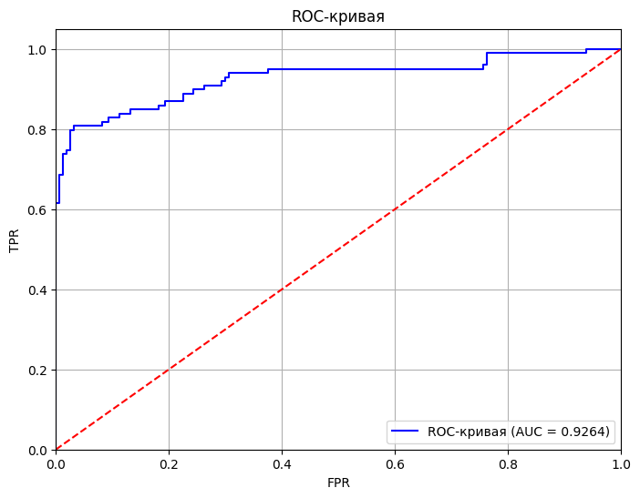

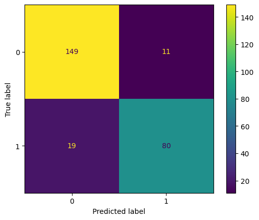

```
Лучшая модель: SVC с параметрами:
```

```
Pipeline(steps=[('preprocessor',
                 ColumnTransformer(remainder='passthrough',
                                   transformers=[('ohe',
                                                  Pipeline(steps=[('simpleImputer_ohe',
                                                                   SimpleImputer(strategy='most_frequent')),
                                                                  ('ohe',
                                                                   OneHotEncoder(drop='first',
                                                                                 sparse_output=False))]),
                                                  ['тип_сервиса',
                                                   'разрешить_сообщать',
                                                   'популярная_категория']),
                                                 ('ord',
                                                  Pipeline(steps=[('simpleImputer_before_ord',
                                                                   SimpleI...
                                                   'длительность',
                                                   'средний_просмотр_категорий_за_визит',
                                                   'неоплаченные_продукты_штук_квартал',
                                                   'ошибка_сервиса',
                                                   'страниц_за_визит',
                                                   'препредыдущий_месяц_выручка',
                                                   'предыдущий_месяц_выручка',
                                                   'текущий_месяц_выручка',
                                                   'предыдущий_месяц_минут',
                                                   'текущий_месяц_минут'])])),
                ('models',
                 SVC(C=89.31066986758924, gamma=0.2701807036080126,
                     probability=True, random_state=42))])
```

```
Лучшая оценка ROC_AUC (кросс-валидация) на обучающем наборе: 0.9150132506261286
ROC-AUC оценка на валидационном наборе: 0.9131313131313131
```

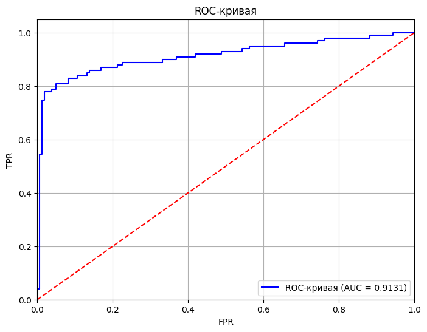

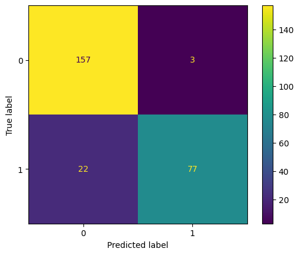

|  | params | best_estimator | best_score | roc_auc_test |
| --- | --- | --- | --- | --- |
| 0 | {'models': CategoricalDistribution(choices=(De... | (ColumnTransformer(remainder='passthrough',\n ... | 0.883203 | 0.894539 |
| 1 | {'models': CategoricalDistribution(choices=(KN... | (ColumnTransformer(remainder='passthrough',\n ... | 0.894139 | 0.904924 |
| 2 | {'models': CategoricalDistribution(choices=(Lo... | (ColumnTransformer(remainder='passthrough',\n ... | 0.894641 | 0.926389 |
| 3 | {'models': CategoricalDistribution(choices=(SV... | (ColumnTransformer(remainder='passthrough',\n ... | 0.915013 | 0.913131 |

```
CPU times: user 41 s, sys: 961 ms, total: 41.9 s
Wall time: 41 s
```

```python
%%time

best_optuna_model, optuna_models_dict, results_df = \
find_best_model_optuna(
    pipe_final,
    param_grid_optuna
)
print()
```

```python
for key, model in optuna_models_dict.items():
    # Сохраним результаты в соответствующие списки
    pipelines_names.append(f"optuna_models_dict['{key}']")  # Сохраняем имя модели
    pipelines.append(model)       # Сохраняем саму модель

    model.fit(X_train, y_train)

    # Получаем AUC
    train_auc_cv.append(cross_val_score(model, X_train, y_train, cv=5, scoring='roc_auc').mean())
    valid_auc.append(roc_auc_score(y_valid, model.predict_proba(X_valid)[:,1]))
```

Выведем лучшую модель в результате поиска OptunaSearchCV и ее метрики:

```python
best_optuna_model
```

```
Pipeline(steps=[('preprocessor',
                 ColumnTransformer(remainder='passthrough',
                                   transformers=[('ohe',
                                                  Pipeline(steps=[('simpleImputer_ohe',
                                                                   SimpleImputer(strategy='most_frequent')),
                                                                  ('ohe',
                                                                   OneHotEncoder(drop='first',
                                                                                 sparse_output=False))]),
                                                  ['тип_сервиса',
                                                   'разрешить_сообщать',
                                                   'популярная_категория']),
                                                 ('ord',
                                                  Pipeline(steps=[('simpleImputer_before_ord',
                                                                   SimpleI...
                                                   'длительность',
                                                   'средний_просмотр_категорий_за_визит',
                                                   'неоплаченные_продукты_штук_квартал',
                                                   'ошибка_сервиса',
                                                   'страниц_за_визит',
                                                   'препредыдущий_месяц_выручка',
                                                   'предыдущий_месяц_выручка',
                                                   'текущий_месяц_выручка',
                                                   'предыдущий_месяц_минут',
                                                   'текущий_месяц_минут'])])),
                ('models',
                 SVC(C=89.31066986758924, gamma=0.2701807036080126,
                     probability=True, random_state=42))])
```

```python
# Получение лучшей оценки на тренировочной выборке
print(f'Метрика ROC-AUC на кросс-валидации (тренировочная выборка): {cross_val_score(best_optuna_model, X_train, y_train, cv=5, scoring="roc_auc").mean()}')

# Прогнозы на валидационном наборе
y_valid_proba = best_optuna_model.predict_proba(X_valid)[:, 1]
roc_auc = roc_auc_score(y_valid, y_valid_proba)

print(f'Метрика ROC-AUC на валидационной выборке: {roc_auc}')
```

```
Метрика ROC-AUC на кросс-валидации (тренировочная выборка): 0.9150132506261286
Метрика ROC-AUC на валидационной выборке: 0.9131313131313131
```